# Estudios de Informática, Multimedia y Telecomunicaciones

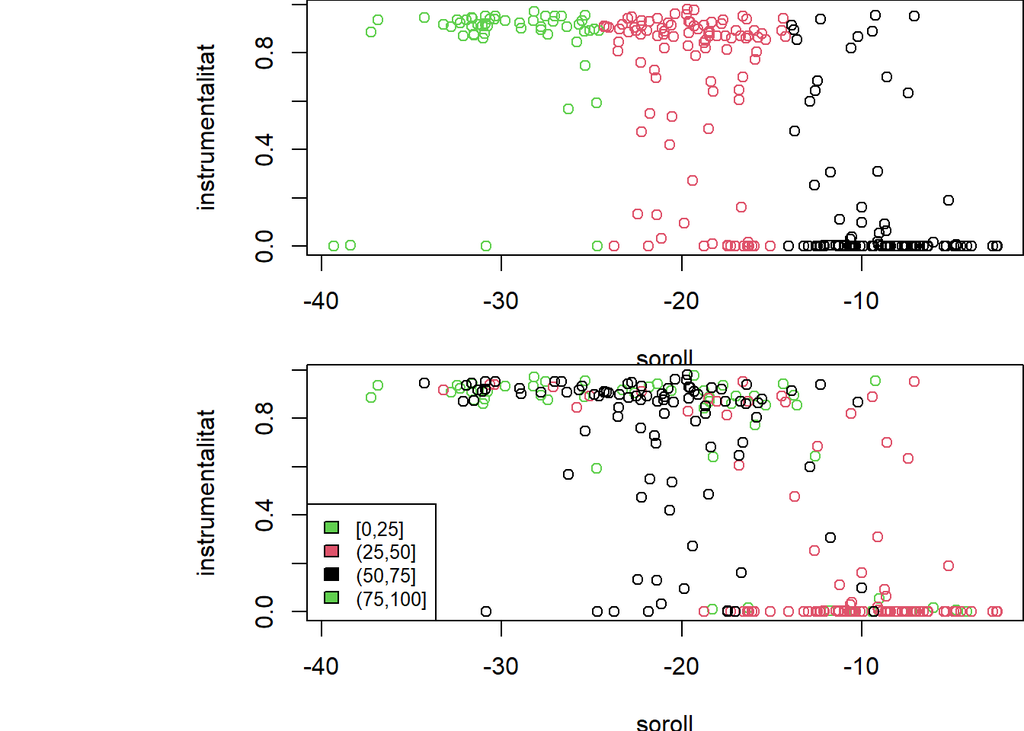

```r
par(mfrow=c(2,1), plt = c(0.3,1,0.3,1))

plot(MeansClassic[c(1,2)], col=MaxClassic3nod$cluster, main= "",xlab="soroll", ylab="instrumentalitat")
plot(Classic[c(5,7)], col=Classic$popularity4, main= "",xlab="soroll", ylab="instrumentalitat")
legend("bottomleft", legend = levels(Classic$popularity4), fill = unique(Classic$popularity4), cex = 0.8)
```

No sembla que hi hagi una millora significativa.

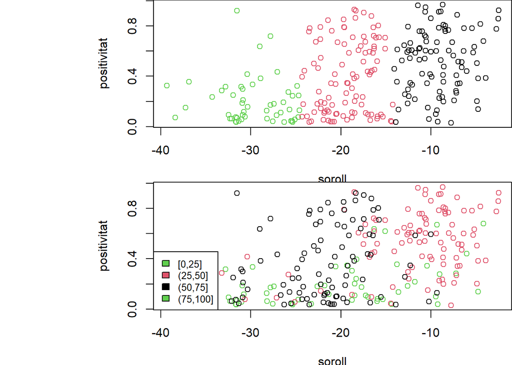

```r
par(mfrow=c(2,1), plt = c(0.3,1,0.3,1))

plot(MeansClassic[c(1,3)], col=MaxClassic3nod$cluster, main= "",xlab="soroll", ylab="positivitat")
plot(Classic[c(5,9)], col=Classic$popularity4, main= "",xlab="soroll", ylab="positivitat")
legend("bottomleft", legend = levels(Classic$popularity4), fill = unique(Classic$popularity4), cex = 0.8)
```

Tampoc classifica millor que amb la distància euclidiana.

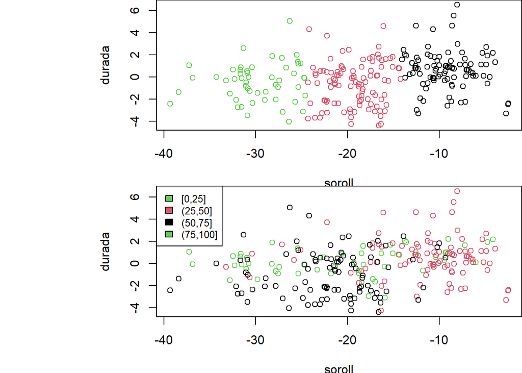

```r
par(mfrow=c(2,1), plt = c(0.3,1,0.3,1))

plot(MeansClassic[c(1,4)], col=MaxClassic3nod$cluster, main= "",xlab="soroll", ylab="durada")
plot(Classic[c(5,12)], col=Classic$popularity4, main= "",xlab="soroll", ylab="durada")
legend("topleft", legend = levels(Classic$popularity4), fill = unique(Classic$popularity4), cex = 0.8)
```

Sembla que classifica una mica millor que amb la distància euclidiana.

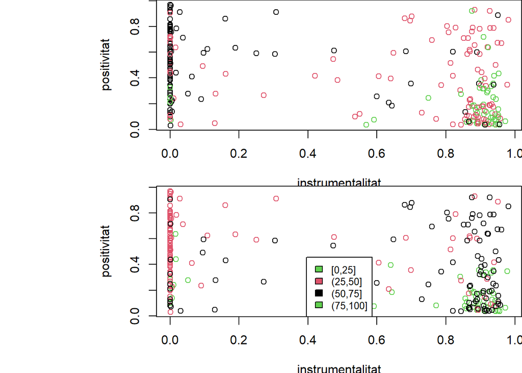

```r
par(mfrow=c(2,1), plt = c(0.3,1,0.3,1))

plot(MeansClassic[c(2,3)], col=MaxClassic3nod$cluster, main= "",xlab="instrumentalitat", ylab="positivitat")
plot(Classic[c(7,9)], col=Classic$popularity4, main= "",xlab="instrumentalitat", ylab="positivitat")
legend("bottom", legend = levels(Classic$popularity4), fill = unique(Classic$popularity4), cex = 0.8)
```

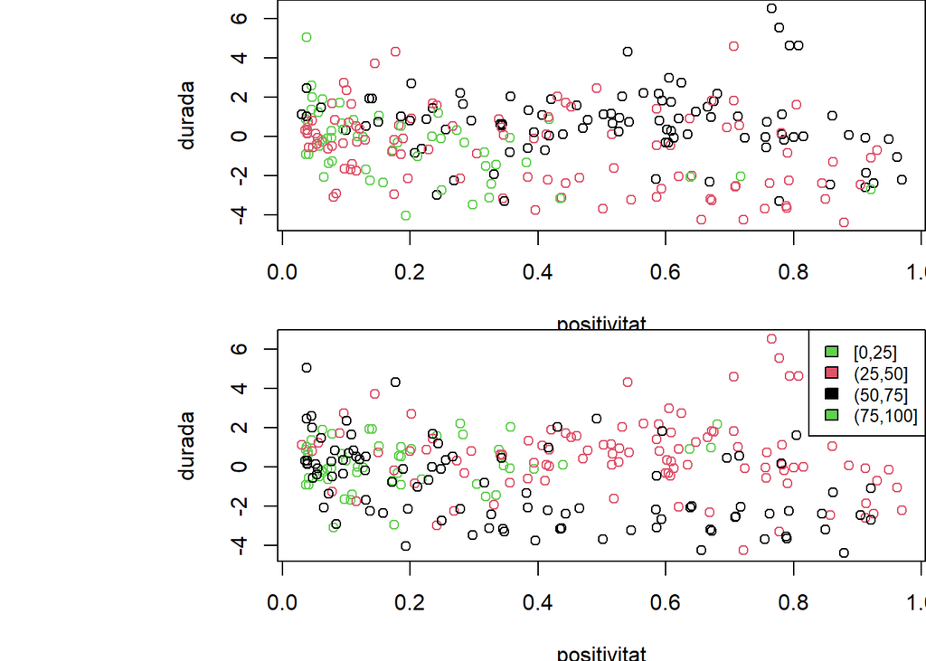

```r
par(mfrow=c(2,1), plt = c(0.3,1,0.3,1))

plot(MeansClassic[c(3,4)], col=MaxClassic3nod$cluster, main= "",xlab="positivitat", ylab="durada")
plot(Classic[c(9,12)], col=Classic$popularity4, main= "",xlab="positivitat", ylab="durada")
legend("topright", legend = levels(Classic$popularity4), fill = unique(Classic$popularity4), cex = 0.8)
```

I aquí també obtenim una millor classificació dels nodes. Podem dir que les cançons positives si duren menys tindran més popularitat que si duren més i que les cançons del gènere clàssic que són negatives i no són curtes tenen una popularitat molt baixa.

#### 1.3.5.1 Conclusions

Com que si que hem obtingut una millora significativa en els darrers gràfics i no un empitjorament amb els dos primers, no sembla una mala idea utilitzar aquesta nova mesura.

De fet, gràcies a aquesta nova mesura podem veure que les cançons de música clàssica negatives tindran menys popularitat que les més positives a no ser que siguin més curtes que la majoria o que no siguin instrumentals.

Per contra, si les cançons de música clàssica són positives, curtes i instrumentals tendeixen a ser més populars.

Ara bé, hem d’anar amb molt de compte amb la fiabilitat d’aquest resultat i estaria bé aplicar altres mètodes com Optics o dbscan.

### 1.3.6 Agrupant la música clàssica amb Optics i dbscan

El primer que farem serà triar un gràfic que ens serveixi per a agrupar per densitat. Pel que hem vist en els anteriors apartats, el gràfic de durada amb la positivitat és una bona opció, donat que el gràfic és:

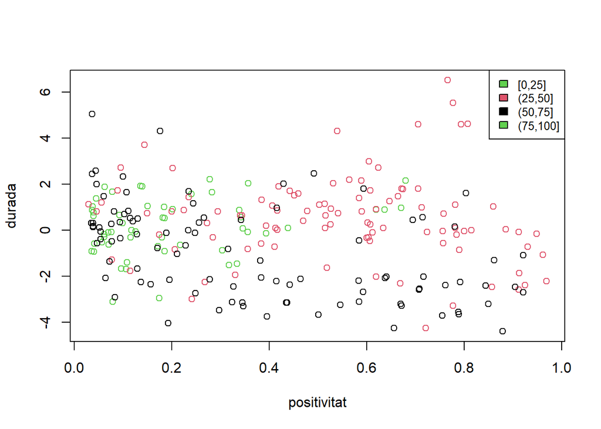

```r
posdur <- Classic[c(9,12)]

plot(posdur, col=Classic$popularity4, main= "",xlab="positivitat", ylab="durada")
legend("topright", legend = levels(Classic$popularity4), fill = unique(Classic$popularity4), cex = 0.8)
```

N’hi ha tres grups prou separats i cadascun d’ells tenen una densitat destacable.

#### 1.3.6.1 Optics

Comencem endreçant les observacions:

```r
if (!require('dbscan')) install.packages('dbscan'); library('dbscan')
```

```r
set.seed(3)
Opt <- optics(posdur, minPts = 10)
Opt
```

```
## OPTICS ordering/clustering for 255 objects.
## Parameters: minPts = 10, eps = 3.80520948224923, eps_cl = NA, xi = NA
## Available fields: order, reachdist, coredist, predecessor, minPts, eps,
##                   eps_cl, xi
```

```r
Opt$order
```

```
##   [1]   1 222 210 181 178 119 225 174 138 118  93  53  47   8  28 113  15   7
##  [19]  36  52  10 244 203 194 183 180 164  24  68 213 216 146  80  22 249  86
##  [37] 199 154  98  87  65  50  46  23   6 101 144 147  58  99 207  55  84 234
##  [55]  66 215  90 187 208 227 205 192 132  41  39  18  16  13  12  54  31  88
##  [73]  32   3 172 253 248  48 108  17 116 105  77 214  38   5 221 230 218 189
##  [91] 176 114  51  43 246  35  21  14   4  76 139  67 117  89  33 152  61 122
## [109]  57 169 129 128 137 109 107 106  82  70  60  56 110 123 228  96  79 155
## [127]  64 175 150 102 240 236 161 115  81 232 143 136 126  71  49  75  27   9
## [145]  45 153  29  34 171  83  73  11 247 224  85 141 111  26  25   2 204 166
## [163]  97 140  92 184 217 219 170 190 226  42  40  69  30  20  19 112 145 250
## [181] 245 243 235 195 212 211 202 229 242 177 168 167 158 151 104 100  63  78
## [199] 209 188 130 220 186  72 191 165 160 159  91 163 131 124 254 238 252 223
## [217] 206 201 198 162 157  95 135  44  37 251 179 182 196 173 193 156 121  74
## [235] 231 255 148 241 239  59 185 127 133 237 200 120 149 197 142 103  94  62
## [253] 233 134 125
```

On veurem que el diagrama d’accessibilitat és:

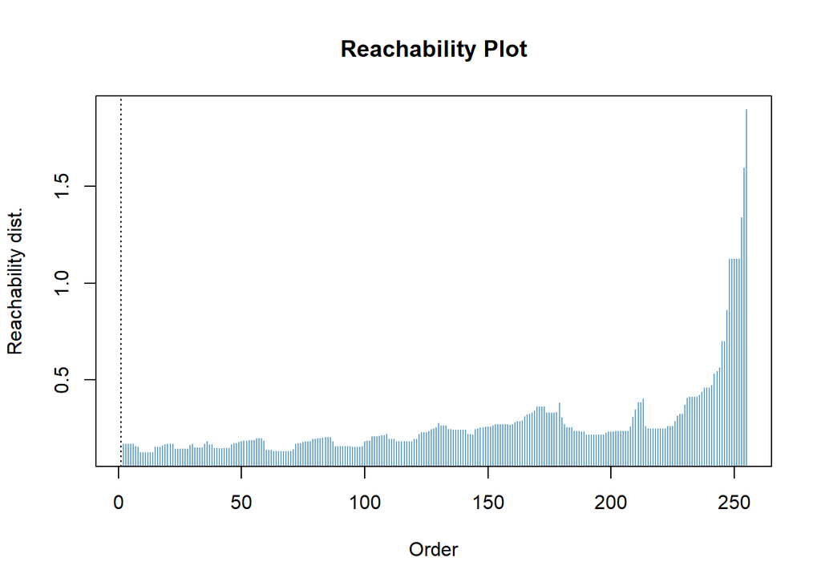

```r
plot(Opt, col="skyblue3")
```

Veiem que tenim una vall marcada i sembla que la nostra idea de tenir tres nodes no és gaire encertada al menys considerant que el mínim de punts és 10. Tot i així, anem a veure quin és el número de clusters més adequat.

Utilitzarem dbscan, el mínim de punts hem dit que eren 10, però quin és el radi que hem de seleccionar?

#### 1.3.6.2 Dbscan

##### 1.3.6.2.1 Canvi de radi

Intentem arribar als dos nodes, pel gràfic sabem que ens trobem al voltant de 0.4:

```r
db1 <- extractDBSCAN(Opt, eps_cl = 0.4)
db1
```

```
## OPTICS ordering/clustering for 255 objects.
## Parameters: minPts = 10, eps = 3.80520948224923, eps_cl = 0.4, xi = NA
## The clustering contains 2 cluster(s) and 25 noise points.
##
##   0   1   2
##  25 212  18
##
## Available fields: order, reachdist, coredist, predecessor, minPts, eps,
##                   eps_cl, xi, cluster
```

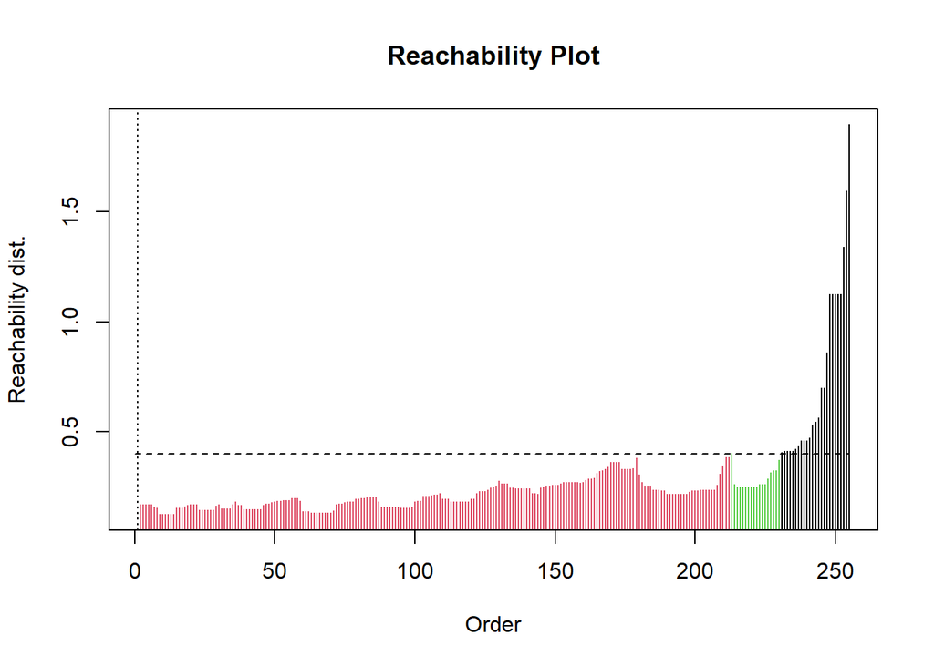

```r
plot(db1)
```

```r
db2 <- extractDBSCAN(Opt, eps_cl = 0.38)
db2
```

```
## OPTICS ordering/clustering for 255 objects.
## Parameters: minPts = 10, eps = 3.80520948224923, eps_cl = 0.38, xi = NA
## The clustering contains 3 cluster(s) and 27 noise points.
##
##   0   1   2   3
##  27 178  32  18
##
## Available fields: order, reachdist, coredist, predecessor, minPts, eps,
##                   eps_cl, xi, cluster
```

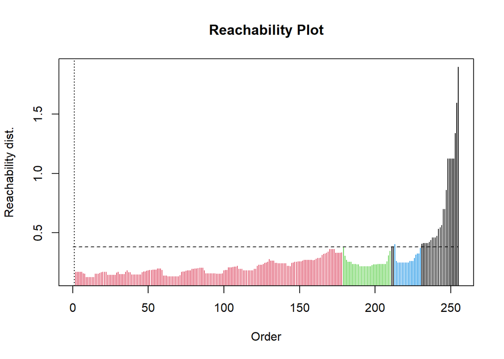

```r
plot(db2)
```

I apropant-nos una mica més podem trobar un èpsilon que ens dona 3 nodes: 0.37.

```r
db3 <- extractDBSCAN(Opt, eps_cl = 0.37)
db3
```

```
## OPTICS ordering/clustering for 255 objects.
## Parameters: minPts = 10, eps = 3.80520948224923, eps_cl = 0.37, xi = NA
## The clustering contains 3 cluster(s) and 28 noise points.
##
##   0   1   2   3
##  28 178  32  17
##
## Available fields: order, reachdist, coredist, predecessor, minPts, eps,
##                   eps_cl, xi, cluster
```

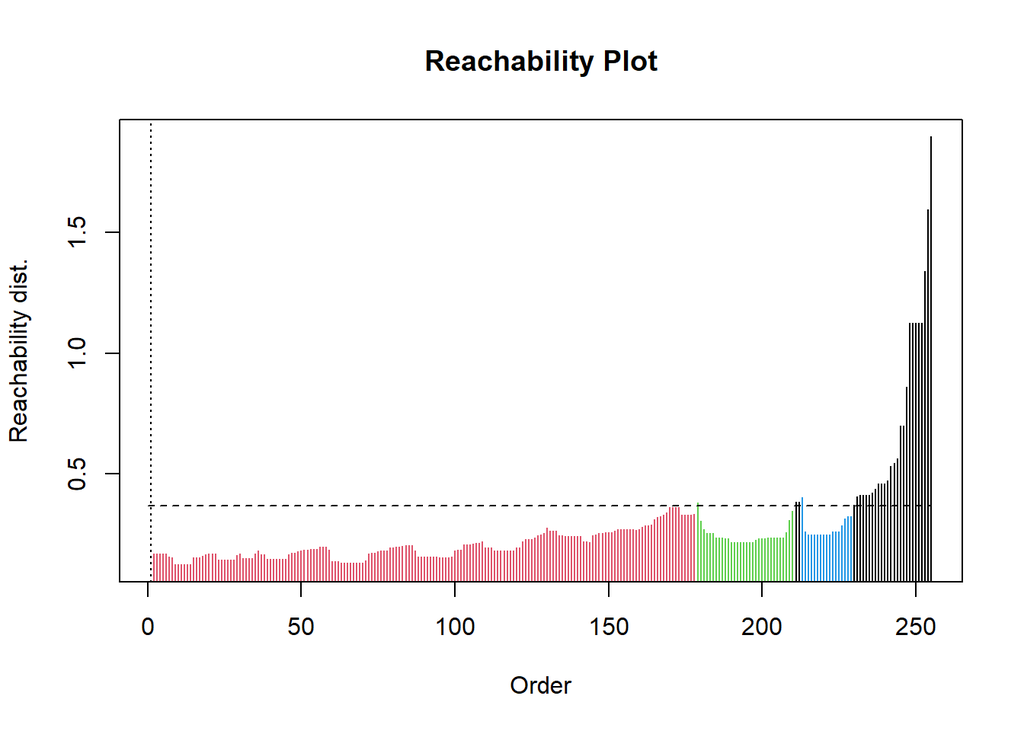

```r
plot(db3)
```

Obtenim dos models diferents un amb èpsilon 0.38 i un amb èpsilon 0.37. Avaluem quin model és més òptim. Calculem l’índex de Calinski-Harabasz per a cadascun d’ells.

```r
posdurMeans2 <- matrix(rep(0,2*max(db2$cluster)), nrow = max(db2$cluster), ncol = 2)

for (i in 0:max(db2$cluster)) {
  posdurMeans2[i,1] <- colMeans(posdur[db2$cluster == i,])[1]
  posdurMeans2[i,2] <- colMeans(posdur[db2$cluster == i,])[2]
}

posdurMeans2
```

```
##           [,1]       [,2]
## [1,] 0.3349669  0.4359565
## [2,] 0.5747937 -2.2881961
## [3,] 0.4691056 -3.2100545
```

```r
suma2 <- 0

for (j in 1:max(db2$cluster)) {
  Gj <- nrow(posdur[db2$cluster == j,])
  suma2 <- suma2+Gj*(colMeans(posdur[1])-posdurMeans2[j,1])^2
}

for (j in 1:max(db2$cluster)) {
  Gj <- nrow(posdur[db2$cluster == j,])
  suma2 <- suma2+Gj*(colMeans(posdur[2])-posdurMeans2[j,2])^2
}

CH2 <- suma2/(max(db2$cluster)-1)
as.numeric(CH2)
```

```
## [1] 189.2544
```

Ara el de 3 nodes:

```r
posdurMeans3 <- matrix(rep(0,2*max(db3$cluster)), nrow = max(db3$cluster), ncol = 2)

for (i in 0:max(db3$cluster)) {
  posdurMeans3[i,1] <- colMeans(posdur[db3$cluster == i,])[1]
  posdurMeans3[i,2] <- colMeans(posdur[db3$cluster == i,])[2]
}

posdurMeans3
```

```
##           [,1]       [,2]
## [1,] 0.3349669  0.4359565
## [2,] 0.5747937 -2.2881961
## [3,] 0.4502882 -3.1844960
```

```r
suma3 <- 0

for (j in 1:max(db3$cluster)) {
  Gj <- nrow(posdur[db3$cluster == j,])
  suma3 <- suma3+Gj*(colMeans(posdur[1])-posdurMeans3[j,1])^2
}

for (j in 1:max(db3$cluster)) {
  Gj <- nrow(posdur[db3$cluster == j,])
  suma3 <- suma3+Gj*(colMeans(posdur[2])-posdurMeans3[j,2])^2
}

CH3 <- suma3/(max(db3$cluster)-1)
as.numeric(CH3)
```

```
## [1] 183.1679
```

##### 1.3.6.2.2 Canvi de mínim de punts

Abans d’analitzar el model de dbscan, canviarem el mínim de punts a 8 a veure si hi ha algun gràfic d’accessibilitat que ens cridi l’atenció per a aplicar un model de 3 nodes:

```r
Opt3 <- optics(posdur, minPts = 8)
Opt3
```

```
## OPTICS ordering/clustering for 255 objects.
## Parameters: minPts = 8, eps = 2.87369241676599, eps_cl = NA, xi = NA
## Available fields: order, reachdist, coredist, predecessor, minPts, eps,
##                   eps_cl, xi
```

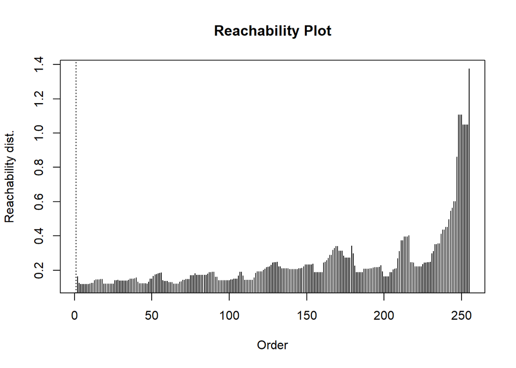

```r
#Opt3$order
plot(Opt3)
```

```r
db3min3 <- extractDBSCAN(Opt3, eps_cl = 0.31)
db3min3
```

```
## OPTICS ordering/clustering for 255 objects.
## Parameters: minPts = 8, eps = 2.87369241676599, eps_cl = 0.31, xi = NA
## The clustering contains 4 cluster(s) and 36 noise points.
##
##   0   1   2   3   4
##  36 166   6  31  16
##
## Available fields: order, reachdist, coredist, predecessor, minPts, eps,
##                   eps_cl, xi, cluster
```

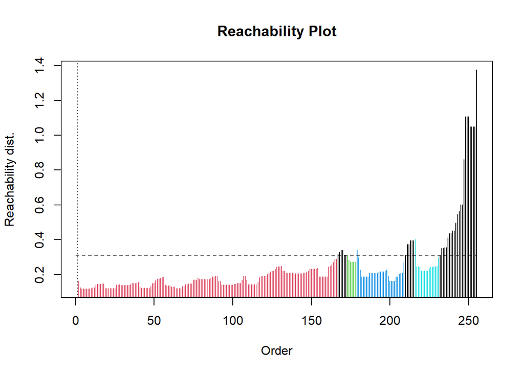

```r
plot(db3min3)
```

```r
db2min3 <- extractDBSCAN(Opt3, eps_cl = 0.32)
db2min3
```

```
## OPTICS ordering/clustering for 255 objects.
## Parameters: minPts = 8, eps = 2.87369241676599, eps_cl = 0.32, xi = NA
## The clustering contains 4 cluster(s) and 30 noise points.
##
##   0   1   2   3   4
##  30 167   9  32  17
##
## Available fields: order, reachdist, coredist, predecessor, minPts, eps,
##                   eps_cl, xi, cluster
```

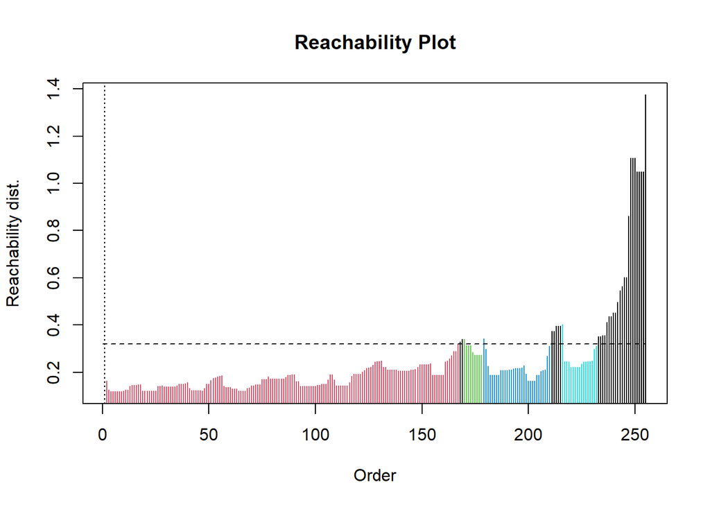

```r
plot(db2min3)
```

Veiem quin és el valor del criteri Calinski-Harabasz d’aquests models:

```r
posdurMeans3min3 <- matrix(rep(0,2*max(db3min3$cluster)), nrow = max(db3min3$cluster), ncol = 2)

for (i in 0:max(db3min3$cluster)) {
  posdurMeans3min3[i,1] <- colMeans(posdur[db3min3$cluster == i,])[1]
  posdurMeans3min3[i,2] <- colMeans(posdur[db3min3$cluster == i,])[2]
}

posdurMeans3min3
```

```
##           [,1]      [,2]
## [1,] 0.3451994  0.531815
## [2,] 0.2473667 -1.554680
## [3,] 0.5853032 -2.273969
## [4,] 0.4598063 -3.166864
```

```r
suma3min3 <- 0

for (j in 1:max(db3min3$cluster)) {
  Gj <- nrow(posdur[db3min3$cluster == j,])
  suma3min3 <- suma3min3+Gj*(colMeans(posdur[1])-posdurMeans3min3[j,1])^2
}

for (j in 1:max(db3min3$cluster)) {
  Gj <- nrow(posdur[db3min3$cluster == j,])
  suma3min3 <- suma3min3+Gj*(colMeans(posdur[2])-posdurMeans3min3[j,2])^2
}

CH3min3 <- suma3min3/(max(db3min3$cluster)-1)
as.numeric(CH3min3)
```

```
## [1] 125.5421
```

```r
posdurMeans2min3 <- matrix(rep(0,2*max(db2min3$cluster)), nrow = max(db2min3$cluster), ncol = 2)

for (i in 0:max(db2min3$cluster)) {
  posdurMeans2min3[i,1] <- colMeans(posdur[db2min3$cluster == i,])[1]
  posdurMeans2min3[i,2] <- colMeans(posdur[db2min3$cluster == i,])[2]
}

posdurMeans2min3
```

```
##           [,1]       [,2]
## [1,] 0.3437311  0.5426007
## [2,] 0.2001889 -1.5707588
## [3,] 0.5747937 -2.2881961
## [4,] 0.4502882 -3.1844960
```

```r
suma2min3 <- 0

for (j in 1:max(db2min3$cluster)) {
  Gj <- nrow(posdur[db2min3$cluster == j,])
  suma2min3 <- suma2min3+Gj*(colMeans(posdur[1])-posdurMeans2min3[j,1])^2
}

for (j in 1:max(db2min3$cluster)) {
  Gj <- nrow(posdur[db2min3$cluster == j,])
  suma2min3 <- suma2min3+Gj*(colMeans(posdur[2])-posdurMeans2min3[j,2])^2
}

CH2min3 <- suma2min3/(max(db2min3$cluster)-1)
as.numeric(CH2min3)
```

```
## [1] 134.5596
```

La representació gràfica de tots dos és:

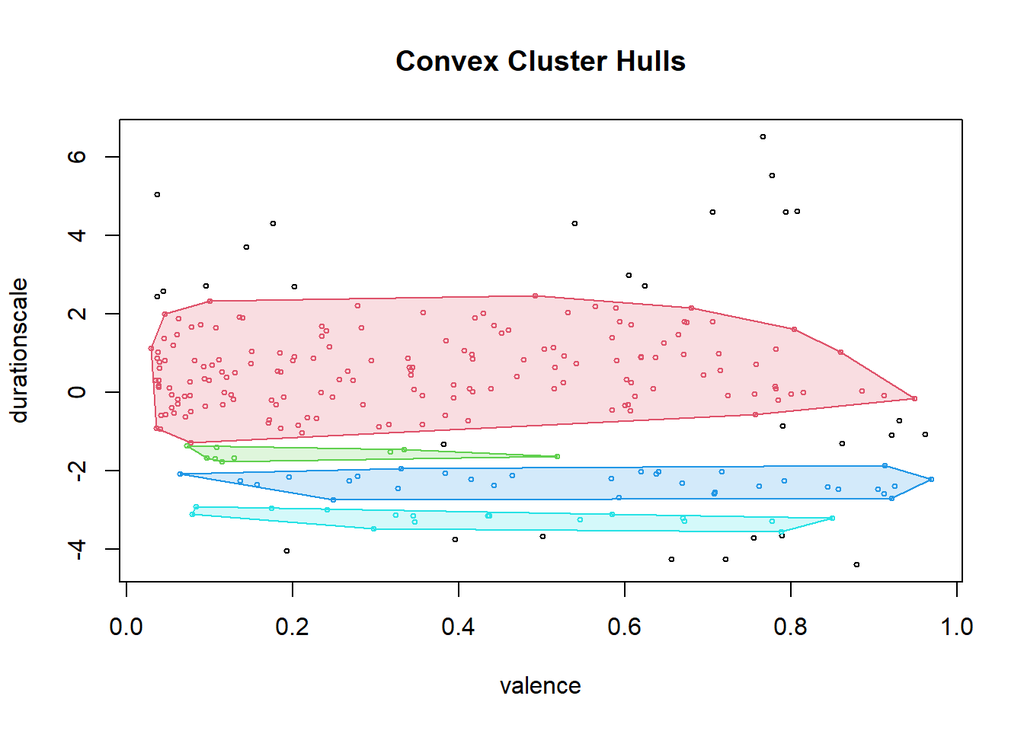

```r
hullplot(posdur, db2min3)
```

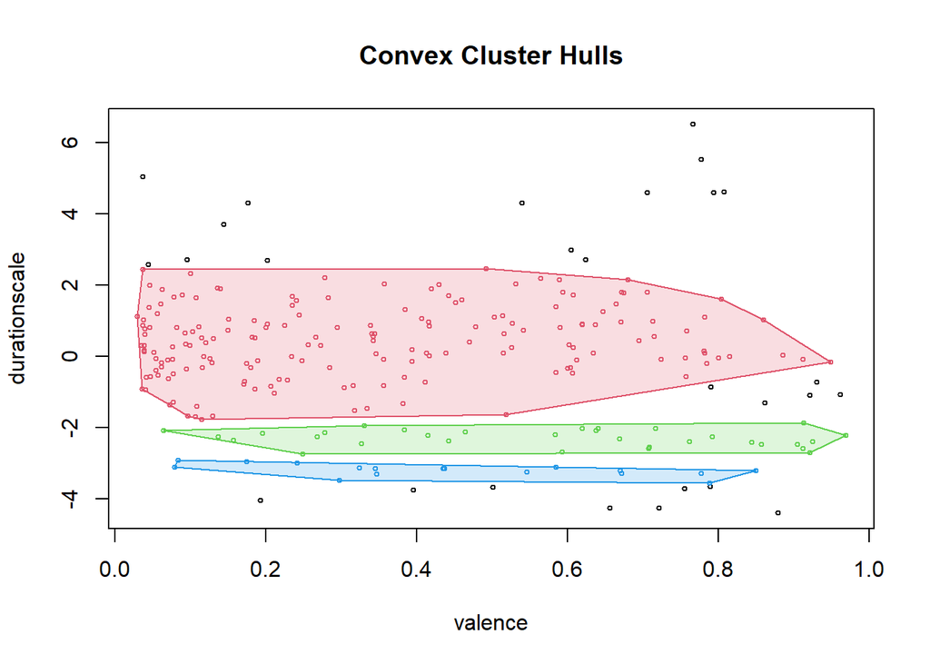

```r
hullplot(posdur, db3)
```

#### 1.3.6.3 Conclusions

Per tant, obtenim que les cançons de música clàssica més curtes són més populars.

A més, aquesta informació confirma les conclusions dels models de k-means que hem fet. Ara bé, és aquest model millor que el de k-means? La resposta és que si que és millor que el model de k-means amb la distància euclidiana però perdem informació respecte el model amb la distància del màxim.

Recordem que el model de k-means amb la distància del màxim ens dona informació dels tres trams de popularitat, podent afirmar que la positivat d’una cançó té efecte en la popularitat. Informació que amb optics i dbscan perdem!

De manera que, de moment, podem afirmar que el millor model per a predir la popularitat de les cançons és el k-means de 3 nodes amb la distància del màxim.

### 1.3.7 Regles pel conjunt total de cançons

Ja hem vist que per alguns gèneres amb unes normes molt definides si que podem agrupar les dades per extreure conclusions respecte a la popularitat. Ara bé, podem aplicar algorismes per entendre la popularitat en la música amb certes regles?

Veiem-ho.

#### 1.3.7.1 Arbres de decisió per trobar regles respecte la popularitat

Començarem aplicant arbres de decisió al joc de dades que tenim.

Ja sabem que el primer que hem de fer és preparar les dades, recordem que necessitem un conjunt d’entrenament i un d’avaluació.

```r
names(Spotifynew)
```

```
##  [1] "track_id"         "popularity"       "explicit"         "key"
##  [5] "loudness"         "mode"             "instrumentalness" "liveness"
##  [9] "valence"          "time_signature"   "track_genre"      "durationscale"
## [13] "popularity4"
```

Veiem que hem d’eliminar el track_id i la popularitat com a enter.

```r
y <- Spotifynew[,13]
X <- Spotifynew[,-c(1,2)]
```

```r
Tauladades <- data.frame()

for(genere in unique(Spotifynew$track_genre)){
  dadesgenere <- subset(Spotifynew, track_genre == genere)

  index <- sample(1:1000, size = 667)

  genereXy <- dadesgenere[index, -2]

  Tauladades <- rbind(Tauladades, genereXy)
}

Tauladades <- Tauladades[!is.na(Tauladades$track_id),]
head(Tauladades)
```

```
##                   track_id explicit key loudness mode instrumentalness liveness
## 773 4OaLdPqqqrtfLPFqSna89W    False   0  -10.504    1         0.00e+00   0.1170
## 698 2Xzh9zjiKhM9YT4AcJxLkQ    False   6   -5.873    1         1.73e-05   0.1560
## 652 7wiULYwv85WeChygucbpTF    False   2   -6.246    0         0.00e+00   0.1360
## 548 34HNaUhhTgO1jvfEuXHFyz     True   2   -8.272    0         2.49e-01   0.0712
## 999 3zVMv0mxjnJRw2BX5ryCqT    False   9   -6.890    1         0.00e+00   0.1780
## 875 57BoKvyN8KbOYkncKzQiD4    False  11   -5.127    1         4.69e-02   0.0781
##     valence time_signature track_genre durationscale popularity4
## 773   0.141              4    acoustic    0.20895931     (25,50]
## 698   0.186              4    acoustic    0.05091926      [0,25]
## 652   0.704              4    acoustic    0.40994445     (25,50]
## 548   0.637              3    acoustic   -0.61747753     (25,50]
## 999   0.412              3    acoustic    0.06543882     (25,50]
## 875   0.490              3    acoustic    0.51840526     (25,50]
```

```r
names(Tauladades)[c(1,12)]
```

```
## [1] "track_id"    "popularity4"
```

```r
TrainX <- Tauladades[,-c(1,12)]
Trainy <- Tauladades[,12]
```

```r
Test <- anti_join(Spotifynew[,-2], Tauladades, by = c("track_id","track_genre","popularity4"))
TestX <- Test[,-c(1,12)]
Testy <- Test[,12]
```

Veiem que no hi han esbiaixaments en la selecció de dades:

```r
summary(TrainX)
```

```
##   explicit          key            loudness            mode
##  False:69324   Min.   : 0.000   Min.   :-49.531   Min.   :0.0000
##  True : 6417   1st Qu.: 2.000   1st Qu.: -9.990   1st Qu.:0.0000
##                Median : 5.000   Median : -6.997   Median :1.0000
##                Mean   : 5.309   Mean   : -8.244   Mean   :0.6383
##                3rd Qu.: 8.000   3rd Qu.: -4.997   3rd Qu.:1.0000
##                Max.   :11.000   Max.   :  4.532   Max.   :1.0000
##
##  instrumentalness       liveness         valence       time_signature
##  Min.   :0.0000000   Min.   :0.0000   Min.   :0.0000   Min.   :0.000
##  1st Qu.:0.0000000   1st Qu.:0.0979   1st Qu.:0.2590   1st Qu.:4.000
##  Median :0.0000418   Median :0.1320   Median :0.4630   Median :4.000
##  Mean   :0.1558180   Mean   :0.2132   Mean   :0.4737   Mean   :3.904
##  3rd Qu.:0.0503000   3rd Qu.:0.2730   3rd Qu.:0.6830   3rd Qu.:4.000
##  Max.   :1.0000000   Max.   :1.0000   Max.   :0.9950   Max.   :5.000
##
##       track_genre    durationscale
##  acoustic   :  667   Min.   :-8.406214
##  afrobeat   :  667   1st Qu.:-0.517064
##  alt-rock   :  667   Median : 0.013797
##  alternative:  667   Mean   : 0.003005
##  bluegrass  :  667   3rd Qu.: 0.554098
##  brazil     :  667   Max.   : 8.409143
##  (Other)    :71739
```

Veiem el resum del conjunt per avaluar les dades:

```r
summary(TestX)
```

```
##   explicit          key           loudness            mode
##  False:34507   Min.   : 0.00   Min.   :-49.307   Min.   :0.0000
##  True : 3301   1st Qu.: 2.00   1st Qu.:-10.008   1st Qu.:0.0000
##                Median : 5.00   Median : -6.998   Median :1.0000
##                Mean   : 5.31   Mean   : -8.243   Mean   :0.6371
##                3rd Qu.: 8.00   3rd Qu.: -5.010   3rd Qu.:1.0000
##                Max.   :11.00   Max.   :  3.156   Max.   :1.0000
##
##  instrumentalness       liveness         valence       time_signature
##  Min.   :0.0000000   Min.   :0.0000   Min.   :0.0000   Min.   :0.000
##  1st Qu.:0.0000000   1st Qu.:0.0981   1st Qu.:0.2620   1st Qu.:4.000
##  Median :0.0000403   Median :0.1320   Median :0.4650   Median :4.000
##  Mean   :0.1554725   Mean   :0.2144   Mean   :0.4752   Mean   :3.905
##  3rd Qu.:0.0454000   3rd Qu.:0.2740   3rd Qu.:0.6840   3rd Qu.:4.000
##  Max.   :1.0000000   Max.   :1.0000   Max.   :0.9940   Max.   :5.000
##
##         track_genre    durationscale
##  acoustic     :  333   Min.   :-6.807179
##  ambient      :  333   1st Qu.:-0.508914
##  anime        :  333   Median : 0.012215
##  breakbeat    :  333   Mean   :-0.001499
##  british      :  333   3rd Qu.: 0.548319
##  chicago-house:  333   Max.   : 7.980572
##  (Other)      :35810
```

```r
prop.table(table(TestX$explicit))
```

```
##
##      False       True
## 0.91269044 0.08730956
```

Comparem les proporcions:

```r
vector <- c(1,2,4,8)

for (i in vector) {
  cat("Proporcions de la variable",names(TestX)[i],":\n\n")
  print(prop.table(table(TestX[i])))
  print(prop.table(table(TrainX[i])))
  cat("\n\n")
}
## Proporcions de la variable explicit :
##
## explicit
##      False       True
## 0.91269044 0.08730956
## explicit
##      False       True
## 0.91527706 0.08472294
##
##
## Proporcions de la variable key :
##
## key
##          0          1          2          3          4          5          6
## 0.11674778 0.09400127 0.10153936 0.03232120 0.07633305 0.08326280 0.06834532
##          7          8          9         10         11
## 0.11563690 0.06337283 0.09931760 0.06596488 0.08315700
## key
##          0          1          2          3          4          5          6
## 0.11343922 0.09487596 0.10238840 0.03070992 0.08033958 0.08155424 0.07006773
##          7          8          9         10         11
## 0.11654190 0.06523547 0.09914049 0.06507704 0.08063004
##
##
## Proporcions de la variable mode :
##
## mode
##         0         1
## 0.3629126 0.6370874
## mode
##        0        1
## 0.361746 0.638254
##
##
## Proporcions de la variable time_signature :
##
## time_signature
##           0           1           3           4           5
## 0.001428269 0.008067076 0.081464240 0.892721117 0.016319298
## time_signature
##           0           1           3           4           5
## 0.001439115 0.008740312 0.079851071 0.894284469 0.015685032

for (i in c(3,5:7,9,10)) {
  cat("Resum de la variable",names(TestX)[i],":\n\n")
  print(summary(TrainX[i]))
  print(summary(TestX[i]))
  cat("\n\n")
}
## Resum de la variable loudness :
##
##     loudness
##  Min.   :-49.531
##  1st Qu.: -9.990
##  Median : -6.997
##  Mean   : -8.244
##  3rd Qu.: -4.997
##  Max.   :  4.532
##     loudness
##  Min.   :-49.307
##  1st Qu.:-10.008
##  Median : -6.998
##  Mean   : -8.243
##  3rd Qu.: -5.010
##  Max.   :  3.156
##
##
## Resum de la variable instrumentalness :
##
##  instrumentalness
##  Min.   :0.0000000
##  1st Qu.:0.0000000
##  Median :0.0000418
##  Mean   :0.1558180
##  3rd Qu.:0.0503000
##  Max.   :1.0000000
##  instrumentalness
##  Min.   :0.0000000
##  1st Qu.:0.0000000
##  Median :0.0000403
##  Mean   :0.1554725
##  3rd Qu.:0.0454000
##  Max.   :1.0000000
##
##
## Resum de la variable liveness :
##
##     liveness
##  Min.   :0.0000
##  1st Qu.:0.0979
##  Median :0.1320
##  Mean   :0.2132
##  3rd Qu.:0.2730
##  Max.   :1.0000
##     liveness
##  Min.   :0.0000
##  1st Qu.:0.0981
##  Median :0.1320
##  Mean   :0.2144
##  3rd Qu.:0.2740
##  Max.   :1.0000
##
##
## Resum de la variable valence :
##
##     valence
##  Min.   :0.0000
##  1st Qu.:0.2590
##  Median :0.4630
##  Mean   :0.4737
##  3rd Qu.:0.6830
##  Max.   :0.9950
##     valence
##  Min.   :0.0000
##  1st Qu.:0.2620
##  Median :0.4650
##  Mean   :0.4752
##  3rd Qu.:0.6840
##  Max.   :0.9940
##
##
## Resum de la variable track_genre :
##
##       track_genre
##  acoustic   :  667
##  afrobeat   :  667
##  alt-rock   :  667
##  alternative:  667
##  bluegrass  :  667
##  brazil     :  667
##  (Other)    :71739
##         track_genre
##  acoustic     :  333
##  ambient      :  333
##  anime        :  333
##  breakbeat    :  333
##  british      :  333
##  chicago-house:  333
##  (Other)      :35810
##
##
## Resum de la variable durationscale :
##
##  durationscale
##  Min.   :-8.406214
##  1st Qu.:-0.517064
##  Median : 0.013797
##  Mean   : 0.003005
##  3rd Qu.: 0.554098
##  Max.   : 8.409143
##  durationscale
##  Min.   :-6.807179
##  1st Qu.:-0.508914
##  Median : 0.012215
##  Mean   :-0.001499
##  3rd Qu.: 0.548319
##  Max.   : 7.980572
```

Les proporcions i els resums ens diuen que hem fet una bona partició de les dades i, per tant, podem continuar.

##### 1.3.7.1.1 Construcció de l’arbre de decisió

Anem a crear el model.

```r
if(!require(ggpubr)){
    install.packages('ggpubr', repos='http://cran.us.r-project.org')
    library(ggpubr)
}
if(!require(C50)){
    install.packages('C50', repos='http://cran.us.r-project.org')
    library(C50)
}
arbre1 <- C50::C5.0(TrainX,Trainy, rules = TRUE)
sum <- summary(arbre1)
```

Obtenim un model amb moltes normes:

```r
library(stringr)
normes <- unlist(strsplit(sum$output, "\n\nRule "))
length(normes)
```

```
## [1] 994
```

En concret 994, per tant anem a fer un data frame per a utilitzar aquestes normes d’una manera senzilla:

```r
Normes <- data.frame(Norma = integer(),
                     Parentesi = character(),
                     Condicions = character(),
                     Classe = character(),
                     Probabilitat = numeric()
                     )

Normes <- Normes[seq_len(length(normes) - 2), ]

for (i in 2:(length(normes)-1)) {
  Normes$Norma[i-1] <- as.integer(str_extract(normes[i], "^\\d+"))
  Normes$Parentesi[i-1] <- str_extract(normes[i], "\\(.*?\\)")
  Normes$Condicions[i-1] <- str_extract(normes[i], "(?s)\\)\n\t(.*)\n\t->")
  Normes$Classe[i-1] <- str_extract(normes[i], "class (\\(|\\[)[^\\]]*\\]")
  Normes$Probabilitat[i-1] <- as.numeric(str_extract(normes[i], "(?<=\\[)[0-9.]+(?=\\])"))
}
```

```r
head(Normes)
```

```
##      Norma        Parentesi
## NA       1   (40, lift 2.5)
## NA.1     2   (32, lift 2.5)
## NA.2     3   (30, lift 2.5)
## NA.3     4   (28, lift 2.5)
## NA.4     5   (28, lift 2.5)
## NA.5     6 (58/1, lift 2.5)
##                                                                                                                                                                                                  Condicions
## NA                                 )\n\tkey <= 10\n\tloudness > -4.364\n\tinstrumentalness <= 0\n\tliveness <= 0.498\n\ttrack_genre in {singer-songwriter, songwriter}\n\tdurationscale > -0.09028482\n\t->
## NA.1                       )\n\texplicit = False\n\tloudness > -10.835\n\tloudness <= -7.783\n\tliveness <= 0.107\n\tvalence > 0.708\n\ttrack_genre in {alt-rock, indie}\n\tdurationscale > -1.116804\n\t->
## NA.2                                                      )\n\texplicit = False\n\tkey > 6\n\tinstrumentalness > 2.24e-05\n\tvalence > 0.941\n\tvalence <= 0.949\n\ttrack_genre in {dub, rock-n-roll}\n\t->
## NA.3                    )\n\tloudness > -7.311\n\tmode <= 0\n\tinstrumentalness > 0.00014\n\tliveness > 0.225\n\tliveness <= 0.322\n\tvalence <= 0.807\n\ttrack_genre in {alt-rock, indie, indie-pop}\n\t->
## NA.4 )\n\texplicit = False\n\tkey <= 0\n\tloudness > -6.391\n\tloudness <= -3.274\n\tliveness > 0.0707\n\tvalence > 0.734\n\ttrack_genre in {latino, reggae, reggaeton}\n\tdurationscale > -0.4410876\n\t->
## NA.5                                                                                                             )\n\tloudness > -6.458\n\ttime_signature <= 3\n\ttrack_genre in {dance, latin, rock}\n\t->
##            Classe Probabilitat
## NA   class [0,25]        0.976
## NA.1 class [0,25]        0.971
## NA.2 class [0,25]        0.969
## NA.3 class [0,25]        0.967
## NA.4 class [0,25]        0.967
## NA.5 class [0,25]        0.967
```

Ens interessen les normes que més encerten a l’hora de classificar les dades. Mirarem les tres primeres, com que per l’extracció de les normes les obtenim endreçades, només cal fer el següent:

```r
cat(Normes[1,2], Normes[1,3], Normes[1,4], Normes[1,5],"\n")
```

```
## (40, lift 2.5) )
##  key <= 10
##  loudness > -4.364
##  instrumentalness <= 0
##  liveness <= 0.498
##  track_genre in {singer-songwriter, songwriter}
##  durationscale > -0.09028482
##  -> class [0,25] 0.976
```

```r
cat(Normes[1,2], Normes[2,3], Normes[2,4], Normes[2,5],"\n")
```

```
## (40, lift 2.5) )
##  explicit = False
##  loudness > -10.835
##  loudness <= -7.783
##  liveness <= 0.107
##  valence > 0.708
##  track_genre in {alt-rock, indie}
##  durationscale > -1.116804
##  -> class [0,25] 0.971
```

```r
cat(Normes[1,2], Normes[3,3], Normes[3,4], Normes[3,5],"\n")
```

```
## (40, lift 2.5) )
##  explicit = False
##  key > 6
##  instrumentalness > 2.24e-05
##  valence > 0.941
##  valence <= 0.949
##  track_genre in {dub, rock-n-roll}
##  -> class [0,25] 0.969
```

La segona regla ens diu que les cançons dels gèneres rock alternatiu i indie, que no són explícites, que són o molt sorolloses o molt poc, gravades en estudi, molt positives i llargues també tenen una gran probabilitat de no ser populars.

En general, d’aquestes dades podem extreure que el gènere és molt important a l’hora de saber quins paràmetres són els que defineixen la probabilitat de que una cançó no sigui popular. I, de fet, si fem el summary sense les regles podem trobar la representació de l’arbre i els atributs més importants.

```r
arbre1 <- C50::C5.0(TrainX,Trainy)
#summary(arbre1)
```

On obtenim que el gènere és l’atribut més important, seguit del volum i si la cançó és explícita o no. I, a més, obtenim que l’error és del 22%, que és alt però no terrible i podem veure que classifica molt bé les cançons amb poca popularitat. Veiem si el model és vàlid.

##### 1.3.7.1.2 Validació del model

Utilitzarem el conjunt d’avaluació per a analitzar la qualitat del model.

```r
prediccio_arbre1 <- predict(arbre1,TestX, type="class")
cat("La predicció de l'arbre 1 és:", 100*sum(prediccio_arbre1 == Testy) / length(prediccio_arbre1),"%")
```

```
## La predicció de l'arbre 1 és: 66.3431 %
```

La predicció és molt baixa. Veiem la matriu de confusió:

```r
matriuConf <- table(Testy,Predicted= prediccio_arbre1)
matriuConf
```

```
##           Predicted
## Testy      [0,25] (25,50] (50,75] (75,100]
##   [0,25]    11553    1922    1062      112
##   (25,50]    2783    9089    2068       51
##   (50,75]    1499    2470    4312      113
##   (75,100]    308      87     250      129
```

I, amb aquesta matriu:

```r
percentcorrecte <- 100*sum(diag(matriuConf))/sum(matriuConf)
cat("El percentatge de registres correctament classificats és:",percentcorrecte,"%")
```

```
## El percentatge de registres correctament classificats és: 66.3431 %
```

Ja veiem que, en general, aquest model és prou dolent per predir la popularitat. Però, hi ha algun tram de popularitat que classifiqui prou bé?

```r
if(!require(gmodels)){
    install.packages('gmodels', repos='http://cran.us.r-project.org')
    library(gmodels)
}
CrossTable(Testy, prediccio_arbre1, prop.chisq = FALSE, prop.r = FALSE, prop.c = FALSE, dnn = c('Realitat', 'Prediccio'))
```

```
##
##
##    Cell Contents
## |-------------------------|
## |                       N |
## |         N / Table Total |
## |-------------------------|
##
##
## Total Observations in Table:  37808
##
##
##              | Prediccio
##     Realitat |    [0,25] |   (25,50] |   (50,75] |  (75,100] | Row Total |
## -------------|-----------|-----------|-----------|-----------|-----------|
##       [0,25] |     11553 |      1922 |      1062 |       112 |     14649 |
##              |     0.306 |     0.051 |     0.028 |     0.003 |           |
## -------------|-----------|-----------|-----------|-----------|-----------|
##      (25,50] |      2783 |      9089 |      2068 |        51 |     13991 |
##              |     0.074 |     0.240 |     0.055 |     0.001 |           |
## -------------|-----------|-----------|-----------|-----------|-----------|
##      (50,75] |      1499 |      2470 |      4312 |       113 |      8394 |
##              |     0.040 |     0.065 |     0.114 |     0.003 |           |
## -------------|-----------|-----------|-----------|-----------|-----------|
##     (75,100] |       308 |        87 |       250 |       129 |       774 |
##              |     0.008 |     0.002 |     0.007 |     0.003 |           |
## -------------|-----------|-----------|-----------|-----------|-----------|
## Column Total |     16143 |     13568 |      7692 |       405 |     37808 |
## -------------|-----------|-----------|-----------|-----------|-----------|
##
##
```

Molt probablement això es deu a la gran quantitat de dades i per la gran barreja de generes que tenim. Per tant, construirem un nou model però seleccionant un gènere en particular.

En la realització del model de k-means hem obtingut que el Dance tenia una bona proporció de cançons molt populars i cançons que no ho eren tant. Veiem si amb un arbre de decisió obtenim un model per predir si una cançó Dance serà popular o no.

#### 1.3.7.2 Arbre de decisió de la música Dance

##### 1.3.7.2.1 Construcció dels conjunts d’avaluació i entrenament

Primer hem de crear els conjunts que, en aquest cas serà prou fàcil:

```r
DanceTrain <- subset(Tauladades, Tauladades$track_genre == "dance")

DanceTrainX <- DanceTrain[,-c(1,12)]
DanceTrainy <- DanceTrain[,12]
```

I el conjunt d’avaluació:

```r
DanceTest <- subset(Test, Test$track_genre == "dance")

DanceTestX <- DanceTest[,-c(1,12)]
DanceTesty <- DanceTest[,12]
```

##### 1.3.7.2.2 Construcció del model

Una vegada tenim els subconjunts, anem a veure el model que podem construir:

```r
Dance1 <- C50::C5.0(DanceTrainX,DanceTrainy, rules = TRUE)
summary(Dance1)
```

```
##
## Call:
## C5.0.default(x = DanceTrainX, y = DanceTrainy, rules = TRUE)
##
##
## C5.0 [Release 2.07 GPL Edition]      Tue Jun 27 22:46:56 2023
## -------------------------------
##
## Class specified by attribute `outcome'
##
## Read 646 cases (11 attributes) from undefined.data
##
## Rules:
##
## Rule 1: (23, lift 1.4)
##  durationscale > 0.7777129
##  ->  class [0,25]  [0.960]
##
## Rule 2: (13, lift 1.4)
##  instrumentalness > 0.00315
##  durationscale <= -0.521498
##  ->  class [0,25]  [0.933]
##
## Rule 3: (623/200, lift 1.0)
##  durationscale <= 0.7777129
##  ->  class [0,25]  [0.678]
##
## Rule 4: (6, lift 7.4)
##  explicit = False
##  key <= 2
##  liveness > 0.158
##  liveness <= 0.283
##  valence > 0.456
##  valence <= 0.816
##  durationscale <= -0.3650602
##  ->  class (50,75]  [0.875]
##
## Rule 5: (4, lift 7.1)
##  explicit = False
##  loudness > -6.237
```

[output cut: 243 more lines]

```
##
##  Attribute usage:
##
##  100.00% durationscale
##   13.16% key
##   13.16% liveness
##   12.54% mode
##   10.99% explicit
##    9.60% valence
##    7.43% instrumentalness
##    6.66% loudness
##    0.31% time_signature
##
##
## Time: 0.0 secs
```

Aquest model té un error del 15.6% però ja en la distribució del errors podem veure que classifica molt bé les cançons amb poca popularitat.

És interessant veure com la durada de la cançó té tant d’impacte i la resta d’atributs tenen tan poc. Abans d’explicar les regles una a una mirem la representació gràfica de l’arbre:

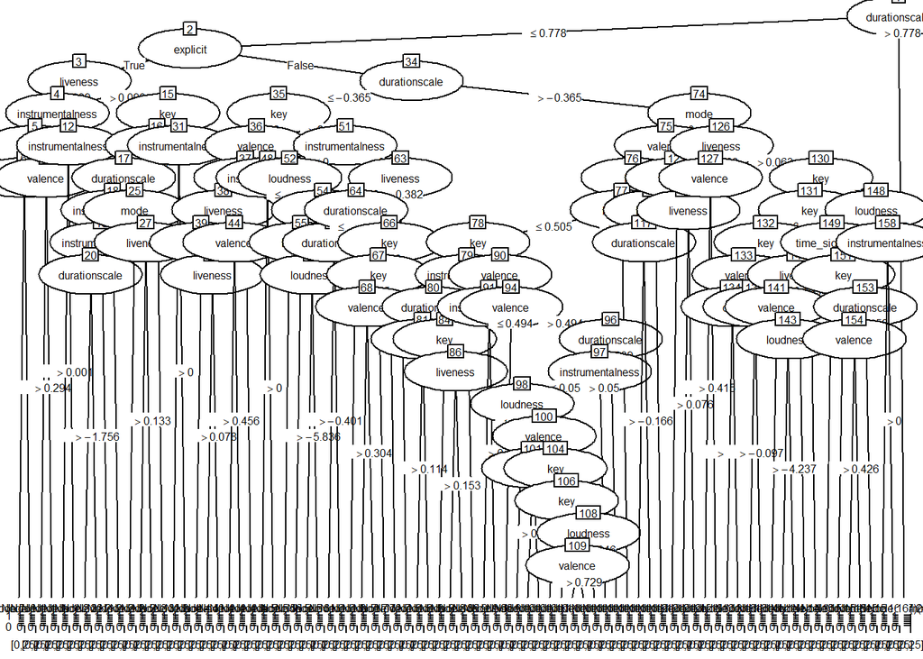

```r
library(C50)
library(grid)

Dance1 <- C50::C5.0(DanceTrainX,DanceTrainy)
plot(Dance1, gp = gpar(fontsize = 6))
```

Veiem que el fet de tenir variables numèriques provoca arbres complexos amb representacions gràfiques difícils d’entendre. Canviarem una mica el conjunt i factoritzarem les variables per a tenir arbres més simples:

Modifiquem les dades:

```r
DanceTrainX2 <- data.frame(
  key = as.factor(DanceTrainX$key),
  loudness = cut(DanceTrainX$loudness, c(-12,-8.5,-5,-1.5), labels = c("baix", "mig", "alt")),
  mode = as.factor(DanceTrainX$mode),
  instrumentalness = cut(DanceTrainX$instrumentalness, c(-0.1,0.25,0.5,0.75,1), labels = c("baixa", "mig baixa", "mig alta", "alta")),
  liveness = cut(DanceTrainX$liveness, c(-0.1,0.25,0.5,0.75,1), labels = c("baixa", "mig baixa", "mig alta", "alta")),
  valence = cut(DanceTrainX$valence, c(-0.1,0.25,0.5,0.75,1), labels = c("baixa", "mig baixa", "mig alta", "alta")),
  time_signature = as.factor(DanceTrainX$time_signature),
  durationscale = cut(DanceTrainX$durationscale, c(-2.05,-1,0,1,2), labels = c("baixa", "mig baixa", "mig alta", "alta"))
)
head(DanceTrainX2)
```

```
##   key loudness mode instrumentalness  liveness   valence time_signature
## 1   7      mig    1            baixa     baixa  mig alta              4
## 2   7      mig    0            baixa mig baixa  mig alta              4
## 3   5      alt    1            baixa     baixa  mig alta              4
## 4  10      alt    1            baixa     baixa mig baixa              4
## 5   0     baix    1            baixa mig baixa  mig alta              3
## 6   2      mig    0            baixa     baixa  mig alta              4
##   durationscale
## 1     mig baixa
## 2     mig baixa
## 3     mig baixa
## 4     mig baixa
## 5         baixa
## 6     mig baixa
```

Ara que tenim totes les variables factoritzades, veiem com canvia l’arbre de decisió:

```r
Dance2 <- C50::C5.0(DanceTrainX2,DanceTrainy, rules = TRUE)
summary(Dance2)
```

```
##
## Call:
## C5.0.default(x = DanceTrainX2, y = DanceTrainy, rules = TRUE)
##
##
## C5.0 [Release 2.07 GPL Edition]      Tue Jun 27 22:47:00 2023
## -------------------------------
##
## Class specified by attribute `outcome'
##
## Read 646 cases (9 attributes) from undefined.data
##
## Rules:
##
## Default class: [0,25]
##
##
## Evaluation on training data (646 cases):
##
##          Rules
##    ----------------
##      No      Errors
##
##       0  200(31.0%)   <<
##
##
##     (a)   (b)   (c)   (d)    <-classified as
##    ----  ----  ----  ----
##     446                      (a): class [0,25]
##       1                      (b): class (25,50]
##      76                      (c): class (50,75]
##     123                      (d): class (75,100]
##
##
## Time: 0.0 secs
```

Observem que aquest model té un error del 31% i ho ha classificat tot com en la popularitat més baixa. Descartarem aquest model i ens quedarem amb l’anterior.

Per tant, anem a validar l’anterior model.

##### 1.3.7.2.3 Validació del model

Calculem la matriu de confusió:

```r
prediccio_Dance1 <- predict(Dance1,TestX, type="class")
matriuConfDance1 <- table(Testy,Predicted= prediccio_Dance1)
matriuConfDance1
```

```
##           Predicted
## Testy      [0,25] (25,50] (50,75] (75,100]
##   [0,25]     9221       0    2605     2823
##   (25,50]    9009       0    2306     2676
##   (50,75]    5334       0    1411     1649
##   (75,100]    467       0     108      199
```

I, amb aquesta matriu:

```r
percentcorrecte <- 100*sum(diag(matriuConfDance1))/sum(matriuConfDance1)
cat("El percentatge de registres correctament classificats és:",percentcorrecte,"%")
```

```
## El percentatge de registres correctament classificats és: 28.64738 %
```

No obtenim una millora significativa davant de l’arbre fet amb totes les dades.

Tot i així, analitzem els errors:

```r
CrossTable(Testy, prediccio_Dance1, prop.chisq = FALSE, prop.r = FALSE, prop.c = FALSE, dnn = c('Realitat', 'Prediccio'))
```

```
##
##
##    Cell Contents
## |-------------------------|
## |                       N |
## |         N / Table Total |
## |-------------------------|
##
##
## Total Observations in Table:  37808
##
##
##              | Prediccio
##     Realitat |    [0,25] |   (50,75] |  (75,100] | Row Total |
## -------------|-----------|-----------|-----------|-----------|
##       [0,25] |      9221 |      2605 |      2823 |     14649 |
##              |     0.244 |     0.069 |     0.075 |           |
## -------------|-----------|-----------|-----------|-----------|
##      (25,50] |      9009 |      2306 |      2676 |     13991 |
##              |     0.238 |     0.061 |     0.071 |           |
## -------------|-----------|-----------|-----------|-----------|
##      (50,75] |      5334 |      1411 |      1649 |      8394 |
##              |     0.141 |     0.037 |     0.044 |           |
## -------------|-----------|-----------|-----------|-----------|
##     (75,100] |       467 |       108 |       199 |       774 |
##              |     0.012 |     0.003 |     0.005 |           |
## -------------|-----------|-----------|-----------|-----------|
## Column Total |     24031 |      6430 |      7347 |     37808 |
## -------------|-----------|-----------|-----------|-----------|
##
##
```

Si hi ha alguna cosa que podem afirmar d’aquest model es que no serveix per a classificar si una cançó serà un èxit, donat que les probabilitats de que encerti són baixíssimes. Malgrat tot, sembla que si que podem crear un model per predir si la cançó serà molt poc popular. El problema és que hem de modificar aquest arbre donat que té una capacitat d’encert que encara és molt millorable.

Provarem a millorar-lo podant l’arbre.

#### 1.3.7.3 Podant l’arbre

Com hem vist en la creació del model aquest arbre utilitza 8 variables, la importància de les quals varia molt:

| Percentage | Atribute usage |
| --- | --- |
| 100.00% | durationscale |
| 13.16% | key |
| 13.16% | liveness |
| 12.54% | mode |
| 10.99% | explicit |
| 9.60% | valence |
| 7.43% | instrumentalness |
| 6.66% | loudness |

Sabem que la durada és un paràmetre que ha de ser-hi donat que la seva utilització és del 100%. Però, milloraria el model si li traiem més variables?

Li retirarem les variables que menys s’utilitzin. Retirarem la signatura perquè la seva participació és molt baixa en la utilització d’atributs i també el gènere donat que només hi ha un.

Ara la part interessant és treure la resta de variables.

Primer traurem el soroll:

```r
Dancesense1 <- C50::C5.0(DanceTrainX[,-c(8,9,3)],DanceTrainy, rules = TRUE)
summary(Dancesense1)
```

```
##
## Call:
## C5.0.default(x = DanceTrainX[, -c(8, 9, 3)], y = DanceTrainy, rules = TRUE)
##
##
## C5.0 [Release 2.07 GPL Edition]      Tue Jun 27 22:47:00 2023
## -------------------------------
##
## Class specified by attribute `outcome'
##
## Read 646 cases (8 attributes) from undefined.data
##
## Rules:
##
## Rule 1: (23, lift 1.4)
##  durationscale > 0.7777129
##  ->  class [0,25]  [0.960]
##
## Rule 2: (13, lift 1.4)
##  instrumentalness > 0.00315
##  durationscale <= -0.521498
##  ->  class [0,25]  [0.933]
##
## Rule 3: (623/200, lift 1.0)
##  durationscale <= 0.7777129
##  ->  class [0,25]  [0.678]
##
## Rule 4: (4, lift 7.1)
##  explicit = False
##  key > 3
##  mode <= 0
##  liveness <= 0.505
##  valence > 0.494
##  durationscale > 0.238595
##  durationscale <= 0.7777129
##  ->  class (50,75]  [0.833]
##
## Rule 5: (4, lift 7.1)
##  explicit = False
##  mode > 0
```

[output cut: 213 more lines]

```
##      66           1    56    (d): class (75,100]
##
##
##  Attribute usage:
##
##  100.00% durationscale
##   10.37% key
##    9.60% mode
##    9.29% valence
##    8.51% liveness
##    8.20% instrumentalness
##    5.88% explicit
##
##
## Time: 0.0 secs
```

```r
Dancesense2 <- C50::C5.0(DanceTrainX[,-c(8,9,3,5)],DanceTrainy, rules = TRUE)
summary(Dancesense2)
```

```
##
## Call:
## C5.0.default(x = DanceTrainX[, -c(8, 9, 3, 5)], y = DanceTrainy, rules = TRUE)
##
##
## C5.0 [Release 2.07 GPL Edition]      Tue Jun 27 22:47:00 2023
## -------------------------------
##
## Class specified by attribute `outcome'
##
## Read 646 cases (7 attributes) from undefined.data
##
## Rules:
##
## Rule 1: (23, lift 1.4)
##  durationscale > 0.7777129
##  ->  class [0,25]  [0.960]
##
## Rule 2: (623/200, lift 1.0)
##  durationscale <= 0.7777129
##  ->  class [0,25]  [0.678]
##
## Rule 3: (4, lift 7.1)
##  key > 3
##  mode <= 0
##  liveness <= 0.109
##  valence <= 0.216
##  durationscale <= 0.7777129
##  ->  class (50,75]  [0.833]
##
## Rule 4: (4, lift 7.1)
##  explicit = False
##  mode > 0
##  liveness <= 0.0628
##  valence > 0.415
##  durationscale > -0.3650602
##  ->  class (50,75]  [0.833]
##
## Rule 5: (4, lift 7.1)
##  key > 7
```

[output cut: 148 more lines]

```
##      48          27     1    (c): class (50,75]
##      80           1    42    (d): class (75,100]
##
##
##  Attribute usage:
##
##  100.00% durationscale
##   11.15% key
##    8.51% liveness
##    7.43% mode
##    7.43% valence
##    6.50% explicit
##
##
## Time: 0.0 secs
```

L’error puja a un 21.1%.

Traiem una altra diferent, la positivitat:

```r
Dancesense3 <- C50::C5.0(DanceTrainX[,-c(8,9,3,7)],DanceTrainy, rules = TRUE)
summary(Dancesense3)
```

```
##
## Call:
## C5.0.default(x = DanceTrainX[, -c(8, 9, 3, 7)], y = DanceTrainy, rules = TRUE)
##
##
## C5.0 [Release 2.07 GPL Edition]      Tue Jun 27 22:47:00 2023
## -------------------------------
##
## Class specified by attribute `outcome'
##
## Read 646 cases (7 attributes) from undefined.data
##
## Rules:
##
## Rule 1: (23, lift 1.4)
##  durationscale > 0.7777129
##  ->  class [0,25]  [0.960]
##
## Rule 2: (13, lift 1.4)
##  instrumentalness > 0.00315
##  durationscale <= -0.521498
##  ->  class [0,25]  [0.933]
##
## Rule 3: (623/200, lift 1.0)
##  durationscale <= 0.7777129
##  ->  class [0,25]  [0.678]
##
## Rule 4: (3, lift 6.8)
##  explicit = False
##  key > 0
##  key <= 2
##  instrumentalness <= 4.06e-06
##  durationscale <= -0.7201474
##  ->  class (50,75]  [0.800]
##
## Rule 5: (2, lift 6.4)
##  explicit = False
##  instrumentalness > 2.01e-06
##  liveness > 0.382
##  durationscale <= -0.3650602
```

[output cut: 187 more lines]

```
##      44          32          (c): class (50,75]
##      75           3    45    (d): class (75,100]
##
##
##  Attribute usage:
##
##  100.00% durationscale
##   10.37% key
##    9.75% liveness
##    9.60% mode
##    7.74% explicit
##    7.28% instrumentalness
##
##
## Time: 0.0 secs
```

L’error baixa però no tan com quan hem eliminat una sola variable i per tant triarem el model de l’arbre sense 1 variables.

[figure not shown]

```r
Dance1podat <- C50::C5.0(DanceTrainX[,-c(8,9,3)],DanceTrainy)
plot(Dance1podat, gp = gpar(fontsize = 3))
```

Validem-lo

##### 1.3.7.3.1 Validació del model

```r
prediccio_Dance1podat <- predict(Dance1podat,TestX[-c(8,9,3)], type="class")
cat("La predicció de l'arbre és:", 100*sum(prediccio_Dance1podat == Testy) / length(prediccio_Dance1podat),"%")
```

```
## La predicció de l'arbre és: 30.89822 %
```

Veiem els errors:

```r
CrossTable(Testy, predict(Dance1podat,TestX[-c(8,9,3)], type="class"), prop.chisq = FALSE, prop.r = FALSE, prop.c = FALSE, dnn = c('Realitat', 'Prediccio'))
```

```
##
##
##    Cell Contents
## |-------------------------|
## |                       N |
## |         N / Table Total |
## |-------------------------|
##
##
## Total Observations in Table:  37808
##
##
##              | Prediccio
##     Realitat |    [0,25] |   (50,75] |  (75,100] | Row Total |
## -------------|-----------|-----------|-----------|-----------|
##       [0,25] |      9895 |      3032 |      1722 |     14649 |
##              |     0.262 |     0.080 |     0.046 |           |
## -------------|-----------|-----------|-----------|-----------|
##      (25,50] |      9558 |      2620 |      1813 |     13991 |
##              |     0.253 |     0.069 |     0.048 |           |
## -------------|-----------|-----------|-----------|-----------|
##      (50,75] |      5484 |      1634 |      1276 |      8394 |
##              |     0.145 |     0.043 |     0.034 |           |
## -------------|-----------|-----------|-----------|-----------|
##     (75,100] |       511 |       110 |       153 |       774 |
##              |     0.014 |     0.003 |     0.004 |           |
## -------------|-----------|-----------|-----------|-----------|
## Column Total |     25448 |      7396 |      4964 |     37808 |
## -------------|-----------|-----------|-----------|-----------|
##
##
```

#### 1.3.7.4 Adaptative boosting sobre el Dance

Aplicarem un model d’arbre de decisió sobre totes les variables amb 100 trials per l’adaptative boosting:

```r
Dance3 <- C50::C5.0(DanceTrainX[,-c(8,9)],DanceTrainy, trials=100, rules = TRUE)
summary(Dance3)
```

```
##
## Call:
## C5.0.default(x = DanceTrainX[, -c(8, 9)], y = DanceTrainy, trials = 100,
##  rules = TRUE)
##
##
## C5.0 [Release 2.07 GPL Edition]      Tue Jun 27 22:47:04 2023
## -------------------------------
##
## Class specified by attribute `outcome'
##
## Read 646 cases (9 attributes) from undefined.data
##
## -----  Trial 0:  -----
##
## Rules:
##
## Rule 0/1: (23, lift 1.4)
##  durationscale > 0.7777129
##  ->  class [0,25]  [0.960]
##
## Rule 0/2: (13, lift 1.4)
##  instrumentalness > 0.00315
##  durationscale <= -0.521498
##  ->  class [0,25]  [0.933]
##
## Rule 0/3: (623/200, lift 1.0)
##  durationscale <= 0.7777129
##  ->  class [0,25]  [0.678]
##
## Rule 0/4: (5, lift 7.3)
##  explicit = False
##  key > 1
##  key <= 2
##  loudness > -5.658
##  valence <= 0.578
##  durationscale <= -0.3650602
##  ->  class (50,75]  [0.857]
##
## Rule 0/5: (4, lift 7.1)
```

[output cut: 1422 more lines]

```
##
##
##  Attribute usage:
##
##  100.00% key
##  100.00% durationscale
##   99.85% valence
##   96.28% explicit
##   90.25% mode
##   81.58% liveness
##   66.72% loudness
##   66.25% instrumentalness
##
##
## Time: 0.1 secs
```

S’ha aturat en 6 trials. L’error sembla que es classifica millor. Veiem si la millora és prou bona aplicant criteris de validació.

##### 1.3.7.4.1 Validació del model

Tornem a aplicar els criteris de validació:

```r
prediccio_Dance3 <- predict(Dance3,TestX, type="class")
cat("La predicció de l'arbre amb adaptative boosting és:", 100*sum(prediccio_Dance3 == Testy) / length(prediccio_Dance3),"%")
```

```
## La predicció de l'arbre amb adaptative boosting és: 33.35008 %
```

El millor arbre és el que té totes les dades. Si bé ens pensàvem que milloraria restringint les dades a un sol gènere, el gènere que hem triat no ha facilitat obtenir arbres amb millors resultats.

Tot i així, no cal desanimar-se. La nostra anàlisi acaba aquí però si que podem estudiar arbres de decisió per a cada gènere en particular i, fins i tot, ens falta aplicar poda i adaptative boosting a totes les dades juntes. També podríem modificar la popularitat i dividir-la en només dos trams: poca popularitat de 0 a 49 i populars de 50 a 100.

Per tant, el temps per a nosaltres és una limitació però hi han opcions de millora i prous paràmetres per modificar com per a trobar un bon model i no rendir-se.

#### 1.3.7.5 Random forest per a totes les dades

El primer que farem és crear un random forest.

```r
if(!require(randomForest)){
  install.packages('randomForest',repos='http://cran.us.r-project.org')
  library(randomForest)
}

if(!require(iml)){
  install.packages('iml', repos='http://cran.us.r-project.org')
  library(iml)
}
```

No podem fer random forest amb més de 53 categories. Per tant, hem de prendre només un gènere musical. Triarem el Dance per veure si podem trobar un model que ens predigui si una cançó serà popular o no.

```r
set.seed(3)
forest <- randomForest(popularity4 ~., data = DanceTrain[,-c(1,10)], ntree = 500)
```

Veiem la impartància de cada variable per a les prediccions:

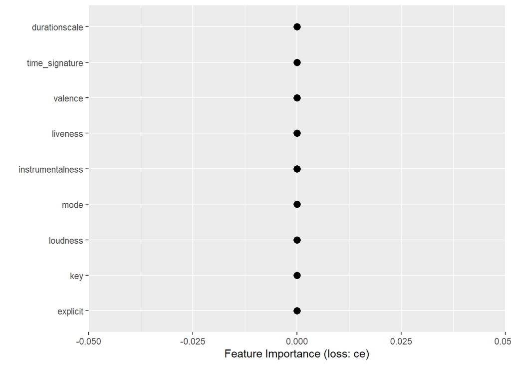

```r
pred <- Predictor$new(forest, data = DanceTrainX[,-9], y = as.numeric(DanceTrainy))
imp <- FeatureImp$new(pred, loss = "ce",compare = "difference")
plot(imp)
```

Totes les variables són igual d’importants. Donem una ullada a les ALE’s per a cada variable:

```r
if(!require(patchwork)){
    install.packages('patchwork',repos='http://cran.us.r-project.org')
    library(patchwork)
}
```

```r
effs <- FeatureEffects$new(pred,grid.size = 30)
```

Representem les ALE’s:

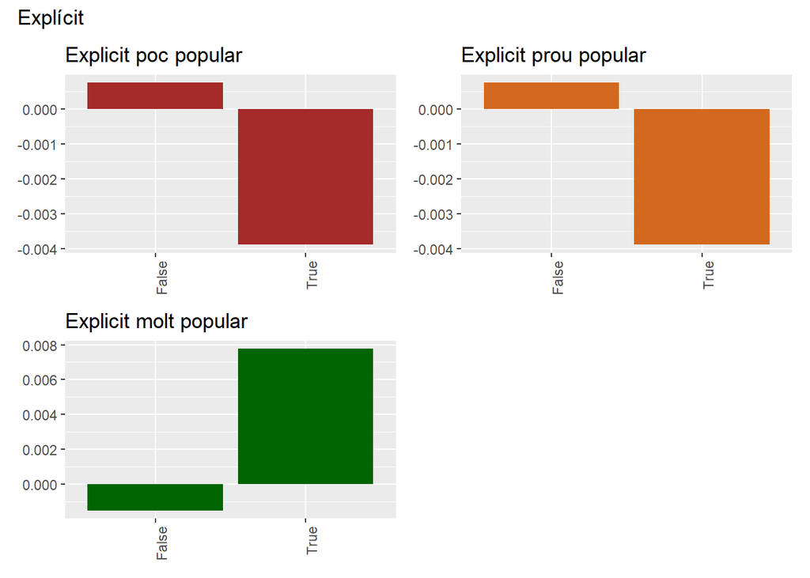

```r
lowexp <- ggplot(effs$results[[1]][effs$results[[1]]$.class == ".0.25.",], aes(x = .borders, y=.value))+
  geom_bar(stat = "identity", fill = "brown")+
  xlab(NULL) + ylab(NULL)+
  ggtitle("Explicit poc popular")+
  theme(axis.text.x = element_text(angle = 90, hjust = 1))

midhighexp <- ggplot(effs$results[[1]][effs$results[[1]]$.class == ".50.75.",], aes(x = .borders, y=.value))+
  geom_bar(stat = "identity", fill = "chocolate")+
  xlab(NULL) + ylab(NULL)+
  ggtitle("Explicit prou popular")+
  theme(axis.text.x = element_text(angle = 90, hjust = 1))

highexp <- ggplot(effs$results[[1]][effs$results[[1]]$.class == ".75.100.",], aes(x = .borders, y=.value))+
  geom_bar(stat = "identity", fill = "darkgreen")+
  xlab(NULL) + ylab(NULL)+
  ggtitle("Explicit molt popular")+
  theme(axis.text.x = element_text(angle = 90, hjust = 1))

lowexp + midhighexp + highexp +
  plot_layout(ncol = 2, widths = c(0.5,0.5)) +
  plot_annotation(title = "Explícit")
```

Com ens podem adonar. Si les lletres són explícites seran molt populars. Té sentit donat que el Dance és un estil de música que agrada a la gent jove, que li poden agradar aquestes lletres per rebels i irreverents.

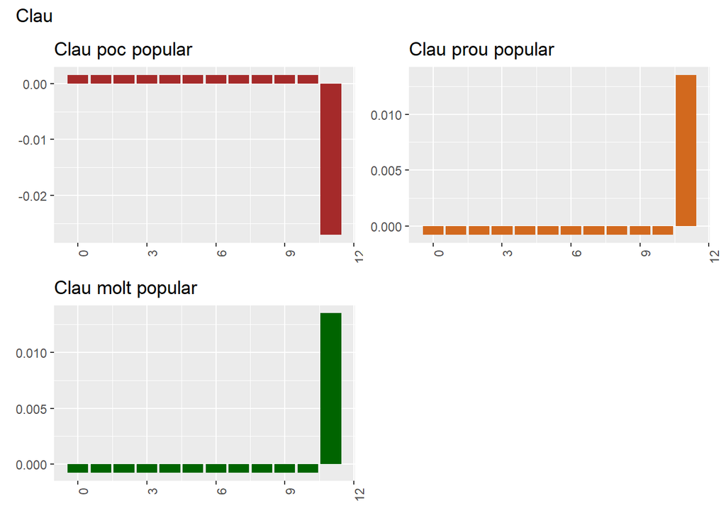

```r
lowkey <- ggplot(effs$results[[2]][effs$results[[2]]$.class == ".0.25.",], aes(x = .borders, y=.value))+
  geom_bar(stat = "identity", fill = "brown")+
  xlab(NULL) + ylab(NULL)+
  ggtitle("Clau poc popular")+
  theme(axis.text.x = element_text(angle = 90, hjust = 1))

midhighkey <- ggplot(effs$results[[2]][effs$results[[2]]$.class == ".50.75.",], aes(x = .borders, y=.value))+
  geom_bar(stat = "identity", fill = "chocolate")+
  xlab(NULL) + ylab(NULL)+
  ggtitle("Clau prou popular")+
  theme(axis.text.x = element_text(angle = 90, hjust = 1))

highkey <- ggplot(effs$results[[2]][effs$results[[2]]$.class == ".75.100.",], aes(x = .borders, y=.value))+
  geom_bar(stat = "identity", fill = "darkgreen")+
  xlab(NULL) + ylab(NULL)+
  ggtitle("Clau molt popular")+
  theme(axis.text.x = element_text(angle = 90, hjust = 1))

lowkey + midhighkey + highkey +
  plot_layout(ncol = 2, widths = c(0.5,0.5)) +
  plot_annotation(title = "Clau")
```

Les cançons més populars estan en clau de Si.

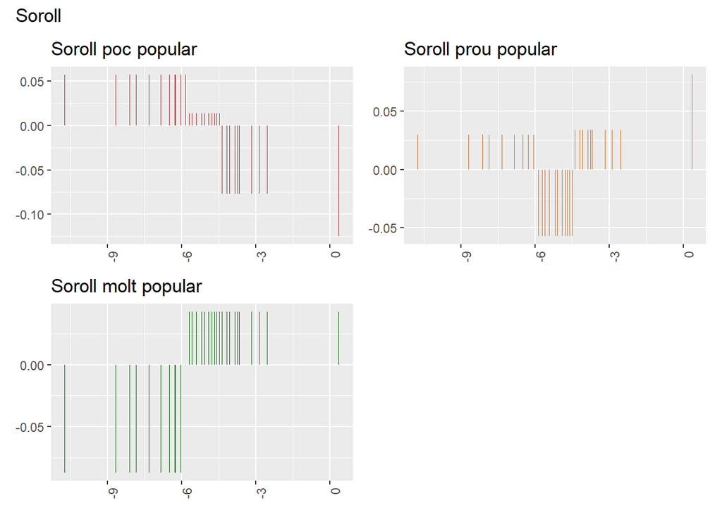

```r
lowlou <- ggplot(effs$results[[3]][effs$results[[3]]$.class == ".0.25.",], aes(x = .borders, y=.value))+
  geom_bar(stat = "identity", fill = "brown")+
  xlab(NULL) + ylab(NULL)+
  ggtitle("Soroll poc popular")+
  theme(axis.text.x = element_text(angle = 90, hjust = 1))

midhighlou <- ggplot(effs$results[[3]][effs$results[[3]]$.class == ".50.75.",], aes(x = .borders, y=.value))+
  geom_bar(stat = "identity", fill = "chocolate")+
  xlab(NULL) + ylab(NULL)+
  ggtitle("Soroll prou popular")+
  theme(axis.text.x = element_text(angle = 90, hjust = 1))

highlou <- ggplot(effs$results[[3]][effs$results[[3]]$.class == ".75.100.",], aes(x = .borders, y=.value))+
  geom_bar(stat = "identity", fill = "darkgreen")+
  xlab(NULL) + ylab(NULL)+
  ggtitle("Soroll molt popular")+
  theme(axis.text.x = element_text(angle = 90, hjust = 1))

lowlou + midhighlou + highlou +
  plot_layout(ncol = 2, widths = c(0.5,0.5)) +
  plot_annotation(title = "Soroll")
```

El resultat que obtenim no és gens estrany. Les cançons amb més volum són les que més popularitat tenen.

[figure not shown]

```r
lowmod <- ggplot(effs$results[[4]][effs$results[[4]]$.class == ".0.25.",], aes(x = .borders, y=.value))+
  geom_bar(stat = "identity", fill = "brown")+
  xlab(NULL) + ylab(NULL)+
  ggtitle("Mode poc popular")+
  theme(axis.text.x = element_text(angle = 90, hjust = 1))

midhighmod <- ggplot(effs$results[[4]][effs$results[[4]]$.class == ".50.75.",], aes(x = .borders, y=.value))+
  geom_bar(stat = "identity", fill = "chocolate")+
  xlab(NULL) + ylab(NULL)+
  ggtitle("Mode prou popular")+
  theme(axis.text.x = element_text(angle = 90, hjust = 1))

lowmod + midhighmod +
  plot_layout(ncol = 2, widths = c(0.5,0.5)) +
  plot_annotation(title = "Mode")
```

No sembla que si la cançó estigui en major o menor influeixi en la popularitat més alta.

[figure not shown]

```r
lowins <- ggplot(effs$results[[5]][effs$results[[5]]$.class == ".0.25.",], aes(x = .borders, y=.value))+
  geom_bar(stat = "identity", fill = "brown")+
  xlab(NULL) + ylab(NULL)+
  ggtitle("Instrumentalitat poc popular")+
  theme(axis.text.x = element_text(angle = 90, hjust = 1))

midhighins <- ggplot(effs$results[[5]][effs$results[[5]]$.class == ".50.75.",], aes(x = .borders, y=.value))+
  geom_bar(stat = "identity", fill = "chocolate")+
  xlab(NULL) + ylab(NULL)+
  ggtitle("Instrumentalitat prou popular")+
  theme(axis.text.x = element_text(angle = 90, hjust = 1))

highins <- ggplot(effs$results[[5]][effs$results[[5]]$.class == ".75.100.",], aes(x = .borders, y=.value))+
  geom_bar(stat = "identity", fill = "darkgreen")+
  xlab(NULL) + ylab(NULL)+
  ggtitle("Instrumentalitat molt popular")+
  theme(axis.text.x = element_text(angle = 90, hjust = 1))

lowins + midhighins + highins +
  plot_layout(ncol = 2, widths = c(0.5,0.5)) +
  plot_annotation(title = "Instrumentalitat")
```

Observem que no sembla que tingui cap influència. Mirem els valors:

```r
head(effs$results[[5]],10)
```

```
##    .type   .class       .value .borders         .feature
## 1    ale   .0.25. -0.044832670 0.00e+00 instrumentalness
## 2    ale  .25.50.  0.000000000 0.00e+00 instrumentalness
## 3    ale  .50.75.  0.051734996 0.00e+00 instrumentalness
## 4    ale .75.100. -0.006902326 0.00e+00 instrumentalness
## 5    ale   .0.25. -0.044832670 1.04e-06 instrumentalness
## 6    ale  .25.50.  0.000000000 1.04e-06 instrumentalness
## 7    ale  .50.75.  0.051734996 1.04e-06 instrumentalness
## 8    ale .75.100. -0.006902326 1.04e-06 instrumentalness
## 9    ale   .0.25. -0.044832670 2.54e-06 instrumentalness
## 10   ale  .25.50.  0.000000000 2.54e-06 instrumentalness
```

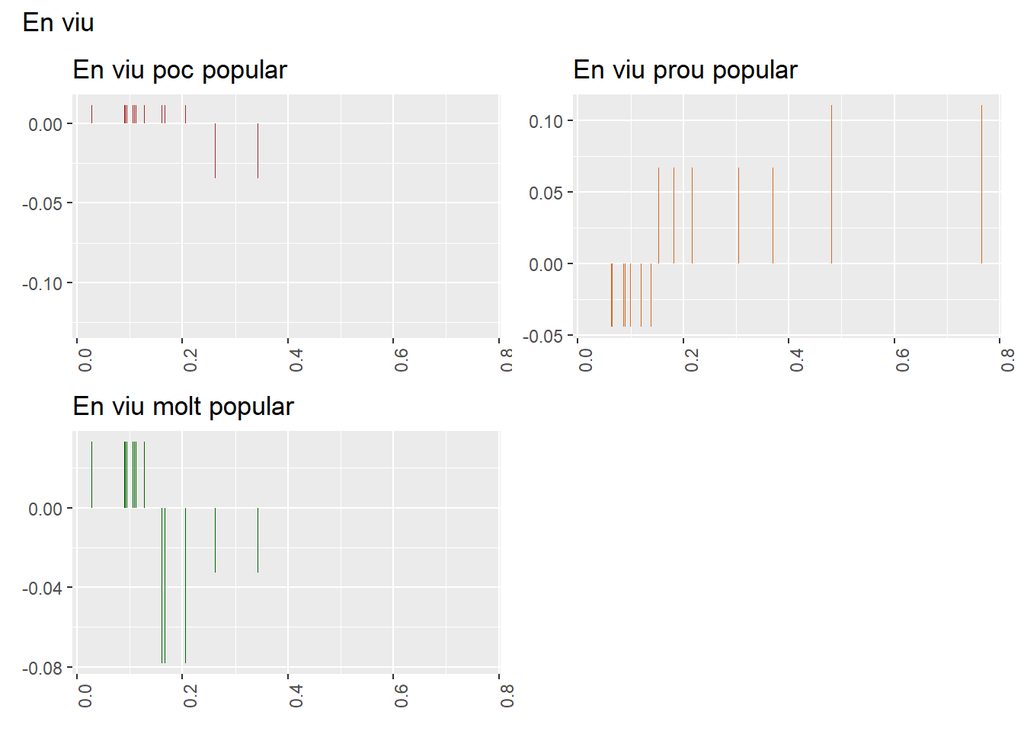

```r
lowviu <- ggplot(effs$results[[6]][effs$results[[6]]$.class == ".0.25.",], aes(x = .borders, y=.value))+
  geom_bar(stat = "identity", fill = "brown")+
  xlab(NULL) + ylab(NULL)+
  ggtitle("En viu poc popular")+
  theme(axis.text.x = element_text(angle = 90, hjust = 1))

midhighviu <- ggplot(effs$results[[6]][effs$results[[6]]$.class == ".50.75.",], aes(x = .borders, y=.value))+
  geom_bar(stat = "identity", fill = "chocolate")+
  xlab(NULL) + ylab(NULL)+
  ggtitle("En viu prou popular")+
  theme(axis.text.x = element_text(angle = 90, hjust = 1))

highviu <- ggplot(effs$results[[6]][effs$results[[6]]$.class == ".75.100.",], aes(x = .borders, y=.value))+
  geom_bar(stat = "identity", fill = "darkgreen")+
  xlab(NULL) + ylab(NULL)+
  ggtitle("En viu molt popular")+
  theme(axis.text.x = element_text(angle = 90, hjust = 1))

lowviu + midhighviu + highviu +
  plot_layout(ncol = 2, widths = c(0.5,0.5)) +
  plot_annotation(title = "En viu")
```

Podem veure com per a que una cançó sigui molt popular no hauria d’estar gravada en directe però tampoc com a un estudi de gravació. Hi ha un punt de gravació amb qualitat d’estudi però que tingui tocs de música en directe petits o subtils. Si ens passem sonant massa en directe, perdrem popularitat ràpidament. Això en referència a la música Dance, altres gèneres segur que reaccionen d’una manera diferent.

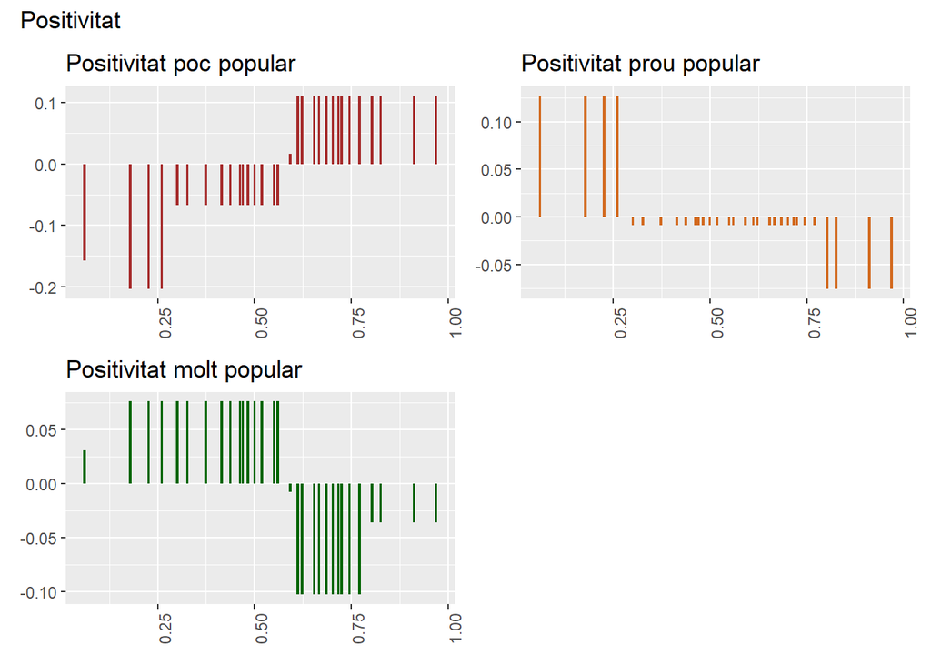

```r
lowval <- ggplot(effs$results[[7]][effs$results[[7]]$.class == ".0.25.",], aes(x = .borders, y=.value))+
  geom_bar(stat = "identity", fill = "brown")+
  xlab(NULL) + ylab(NULL)+
  ggtitle("Positivitat poc popular")+
  theme(axis.text.x = element_text(angle = 90, hjust = 1))

midhighval <- ggplot(effs$results[[7]][effs$results[[7]]$.class == ".50.75.",], aes(x = .borders, y=.value))+
  geom_bar(stat = "identity", fill = "chocolate")+
  xlab(NULL) + ylab(NULL)+
  ggtitle("Positivitat prou popular")+
  theme(axis.text.x = element_text(angle = 90, hjust = 1))

highval <- ggplot(effs$results[[7]][effs$results[[7]]$.class == ".75.100.",], aes(x = .borders, y=.value))+
  geom_bar(stat = "identity", fill = "darkgreen")+
  xlab(NULL) + ylab(NULL)+
  ggtitle("Positivitat molt popular")+
  theme(axis.text.x = element_text(angle = 90, hjust = 1))

lowval + midhighval + highval +
  plot_layout(ncol = 2, widths = c(0.5,0.5)) +
  plot_annotation(title = "Positivitat")
```

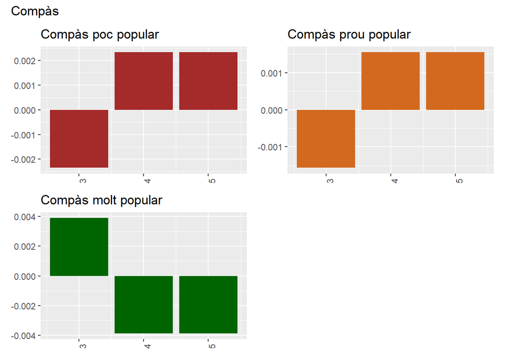

```r
lowtim <- ggplot(effs$results[[8]][effs$results[[8]]$.class == ".0.25.",], aes(x = .borders, y=.value))+
  geom_bar(stat = "identity", fill = "brown")+
  xlab(NULL) + ylab(NULL)+
  ggtitle("Compàs poc popular")+
  theme(axis.text.x = element_text(angle = 90, hjust = 1))

midhightim <- ggplot(effs$results[[8]][effs$results[[8]]$.class == ".50.75.",], aes(x = .borders, y=.value))+
  geom_bar(stat = "identity", fill = "chocolate")+
  xlab(NULL) + ylab(NULL)+
  ggtitle("Compàs prou popular")+
  theme(axis.text.x = element_text(angle = 90, hjust = 1))

hightim <- ggplot(effs$results[[8]][effs$results[[8]]$.class == ".75.100.",], aes(x = .borders, y=.value))+
  geom_bar(stat = "identity", fill = "darkgreen")+
  xlab(NULL) + ylab(NULL)+
  ggtitle("Compàs molt popular")+
  theme(axis.text.x = element_text(angle = 90, hjust = 1))

lowtim + midhightim + hightim +
  plot_layout(ncol = 2, widths = c(0.5,0.5)) +
  plot_annotation(title = "Compàs")
```

Aquest gràfic és prou clar, el compàs més popular és 3/4. També cal tenir en compte que tenim moltes cançons en 4/4 i menys en 3/4 i que ens trobem davant d’un esbiaixament de supervivència, només les cançons en 3/4 que són populars han estat introduïdes a la llista!

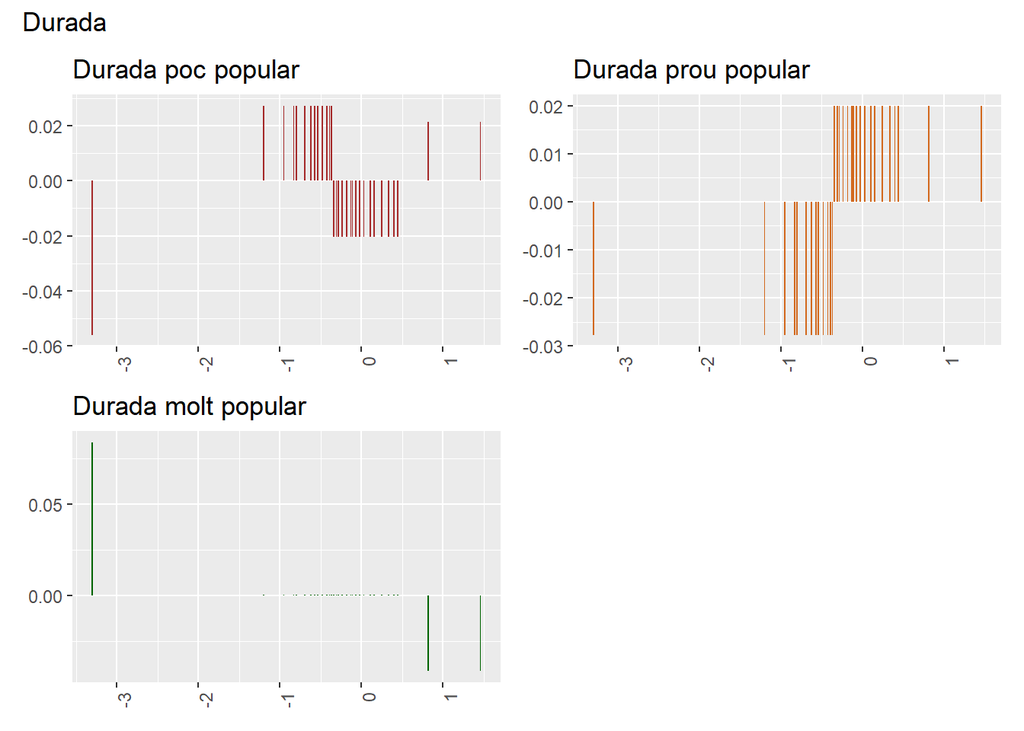

```r
lowdur <- ggplot(effs$results[[9]][effs$results[[9]]$.class == ".0.25.",], aes(x = .borders, y=.value))+
  geom_bar(stat = "identity", fill = "brown")+
  xlab(NULL) + ylab(NULL)+
  ggtitle("Durada poc popular")+
  theme(axis.text.x = element_text(angle = 90, hjust = 1))

midhighdur <- ggplot(effs$results[[9]][effs$results[[9]]$.class == ".50.75.",], aes(x = .borders, y=.value))+
  geom_bar(stat = "identity", fill = "chocolate")+
  xlab(NULL) + ylab(NULL)+
  ggtitle("Durada prou popular")+
  theme(axis.text.x = element_text(angle = 90, hjust = 1))

highdur <- ggplot(effs$results[[9]][effs$results[[9]]$.class == ".75.100.",], aes(x = .borders, y=.value))+
  geom_bar(stat = "identity", fill = "darkgreen")+
  xlab(NULL) + ylab(NULL)+
  ggtitle("Durada molt popular")+
  theme(axis.text.x = element_text(angle = 90, hjust = 1))

lowdur + midhighdur + highdur +
  plot_layout(ncol = 2, widths = c(0.5,0.5)) +
  plot_annotation(title = "Durada")
```

I, com venint confirmant amb tots els models i amb tots els anàlisi de dades que hem fet, les cançons més populars són les més curtes. Podem afegir que, a més les cançons amb una popularitat per sobre de la mitjana però no molt populars són les que duren només una mica més que la mitjana. Però, en general, a més durada menys popularitat.

##### 1.3.7.5.1 Conclusions

Aquest model no té mala pinta per al gènere Dance. Hem descobert que en aquest gènere les lletres explícites triomfen, probablement per l’edat dels que l’escolten; també hem vist que l’escala de Si dona molta popularitat i que el compàs 3/4 és un gran indicador d’èxit. Però també hem confirmat el que ja havíem vist en altres models com que la durada afecta a la popularitat.

En general no sembla un mal model per a triar.

#### 1.3.7.6 Conclusions del treball

En aquest treball hem vist diferents models que ens han portat a les conclusions que explicarem en aquest apartat.

Per començar, en el model de k-means hem vist que:

- Fer un scatter-plot abans de mirar quin número de nodes podem aplicar és molt bona idea. Si no veiem que hi han certs grups en un scatter-plot, només estem perdent temps amb un cost computacional molt elevat.
- Si el número de dades és molt gran, el temps de computació serà desmesurat i els nodes poden no ser comprensibles. Si això passa és millor prendre una mostra de les dades o fer més específica la nostra cerca, per exemple, prenent només un gènere com hem fet nosaltres.
- A vegades volem tenir un número de nodes concret perquè és el que ens sembla correcte. Però k-means va de trobar el número de nodes adequat; sinó tenim molts errors o una classificació poc acurada. Tenim mètodes d’agrupació supervisats per trobar la classificació amb el número de nodes que volem.
- La millor manera de classificar la música clàssica és amb dos nodes.
- Una cançó del gènere de música clàssica tendirà a tenir una popularitat de (25,50] si:

```
* És sorollosa i positiva.
* És molt sorollosa.
* No té instrumentalitat.
* Té una llarga durada.
```

- Si un model de k-means no ens acaba de donar bon resultat, podem canviar-li la distància utilitzada. En el nostre cas hem obtingut millors resultats amb la distància del màxim que amb la distància euclidiana.
- Les cançons de música clàssica negatives tindran menys popularitat que les més positives a no ser que siguin més curtes que la majoria o que no siguin instrumentals.
- Si les cançons de música clàssica són positives, curtes i instrumentals tendeixen a ser més populars.

Una vegada teníem les dades de la música clàssica volíem comprovar si l’agrupació per densitat era millor que k-means.

Aplicant el model optics i dbscan hem obtingut les conclusions:

- El millor model en dbscan i Optics és el de mínim de 8 punts i èpsilon 0.32 On es creen dos clusters: un que indica poca popularitat i un altre que n’indica més.
- Les cançons de música clàssica més curtes són més populars.
- El model que hem dut a terme és millor que el k-means amb la distància euclidiana però no és millor que el k-means amb la distància del màxim. No sempre Optics i dbscan són millors que k-means, cadascun té la seva aplicació.

Posteriorment hem obtingut les dades i regles de tot el conjunt de dades amb arbres de decisió. D’on hem conclòs que:

Per acabar amb els models diferents hem aplicat el random forest i hem vist que:

- No és un model que ajusta prou bé les dades per al gènere Dance.
- Hem descobert que en aquest gènere les lletres explícites triomfen, probablement per l’edat dels que l’escolten; que l’escala de Si dona molta popularitat i que el compàs 3/4 és un gran indicador d’èxit.
- Hem tornat a corroborar que la durada afecta a la popularitat.

També hem extret unes conclusions generals:

- Els models en la vida real no ajusten tan bé com en les dades ja treballades dels exercicis acadèmics.
- El temps que podem dedicar a un projecte de mineria de dades pot ser gairebé il·limitat. Cada vegada que creàvem un model ens sorgien més preguntes o noves maneres de plantejar-nos un problema.

Ara, desprès d’haver treballat amb aquestes dades hem de dir que tenen certes limitacions.

La primera i més important és que tenim molt poques cançons populars. És un fet esperable, però ens esbiaixa les dades. Hagués estat bé haver tallat les cançons per data i veure com evoluciones les cançons populars.

La segona està relacionada amb la primera i és l’esbiaixament de supervivència. Les cançons rock o pop que hi han a la llista tindran més proporció de cançons populars per a tenir cançons populars dins del conjunt sencer de dades. Això produeix un esbiaixament.

La tercera és en referència als gèneres. Com hem pogut veure, la música més formal és més estricta i, per tant, més senzilla de classificar, agrupar i predir. Passa el contrari amb la música pop, que evoluciona al llarg del temps i no ens permet extreure conclusions significatives sobre aquestes cançons.

En general, crec que hagués estat intel·ligent tenir en compte la data en que les cançons van ser populars per a poder fer un estudi més acurat.

Això produeix riscos davant dels models que hem dut a terme. Com que la variabilitat és tan gran, les prediccions són prou dolentes donant com a resultat un model que no prediu més del 70% de les dades.

Segurament si prenem només dos categories: poc popular i molt popular. Podríem tenir models millors. També seria interessant factoritzar les dades numèriques però no en trams iguals si no amb els trams que ens diuen les regles de l’arbre de decisió, per exemple.

Els models que hem triat sempre tendeixen a dir-nos quina cançó serà molt poc popular. I no està malament, recordem que el nostre objectiu era que si no trobàvem els paràmetres per a saber si una cançó seria popular, ens conformaríem amb saber si una cançó està condemnada al fracàs. El que no és correcte és el percentatge de vegades que els models encerten. El que millor ho fa és amb menys del 70% i el que pitjor no arriba ni al 40%.

Per acabar aquesta pràctica, aquests models no han de ser utilitzats, però la feia i les idees que hi han al darrere permeten obrir nous camins en la predicció de la popularitat de les cançons.

## 1.4 Bibliografia

1-. Artificial Intelligence - All in One. (n.d.). Singular Value Decomposition (SVD) - Tutorial. [Video]. YouTube. https://www.youtube.com/watch?v=UyAfmAZU_WI&ab_channel=ArtificialIntelligence-AllinOne

2-. (n.d.). Singular Value Decomposition. Max Planck Institute for Informatics. Retrieved from https://resources.mpi-inf.mpg.de/d5/teaching/ss13/dmm/slides/03-svd-handout.pdf

3-. (n.d.). Singular Value Decomposition. Massachusetts Institute of Technology. Retrieved from https://web.mit.edu/be.400/www/SVD/Singular_Value_Decomposition.htm

4-. (n.d.). Singular Value Decomposition. CiteSeerX. Retrieved from https://citeseerx.ist.psu.edu/document?repid=rep1&type=pdf&doi=e6fc74f9637ee13f352188fd1286f1c0bdad2d80

5-. Facundo González. (n.d.). Singular Value Decomposition (SVD). [Video]. YouTube. https://www.youtube.com/watch?v=lTGw8PkB3ug&ab_channel=FacundoGonz%C3%A1lez

6-. (ChatGPT, communicació personal, Maig 2023).

7-. Minguillón Alfonso, J., & Caihuelas Quiles, R. (2021). Procés de mineria de dades. Primera edició. Barcelona: Fundació Universitat Oberta de Catalunya (FUOC).

8-. Gironés Roig, J. (2021). Gestió de característiques. Primera edició. Barcelona: Fundació Universitat Oberta de Catalunya (FUOC).

9-. Montoliu Colás, R. (2021). Preprocessament de dades. Primera edició. Barcelona: Fundació Universitat Oberta de Catalunya (FUOC).

10-. UC Business Analytics R Programming Guide. (n.d.). K-Means Clustering. Retrieved from https://uc-r.github.io/kmeans_clustering#distance

11-. Marmol Romero, V. (2023) Mineria de dades: PEC2 - Mètodes no supervisats

12-. Marmol Romero, V. (2023) Mineria de dades: PAC3 - Classificació amb arbres de decisió

13-. Marmol Romero, V. (2023) Mineria de dades: PRA1 - Selecció i preparació d’un joc de dades